# Flowering, seed production and germination of Arabis alpina

Supplementary methods, R code and analysis outputs

Gerald Keneth Kaniaru and Samuel Kuria Kiboi

2026

# 1 Study scope and reproducibility

This supplement documents the analysis of flowering phenology, maternal seed traits, and germination in *Arabis alpina* along the Mount Kenya elevational gradient. The analysis covers 581 maternal sampling units from 27 occupied plots. The figures and tables below are read from the saved project outputs and numbered to match the 15 November 2026 manuscript. Use **Show** to inspect the full R code for each stage.

## 1.1 Inputs and run order

Open `arabis analysis.Rproj`. Retain the project structure: `data/` for analysis inputs, `images/` for illustrations and photographs, `scripts/` for R code, and `outputs/` for saved results. The main raw workbooks include `trait_data.xlsx`, `plot_abiotic_factors.xlsx`, and `germination_counts.xlsx` under `data/raw/Datasets/`. The scripts document their other spatial and climate inputs.

Run scripts 01–04 for the study illustrations, 05a for distributions, and 06–10 in order for model outputs. Run 05b after the fitted model objects have been saved. Script 05c generates the correlation figure. The mapping and projection scripts may require external inputs or cached files; review their setup sections before rerunning them.

## 1.2 Render this supplement

From the analysis project root, run:

```r
source("scripts/rmarkdown.R")
```

Rendering assembles the saved figures and tables and displays the source scripts. It does not execute the displayed scripts, refit models, or rerun simulations. The standalone HTML contains display-sized copies of the figures; use the original exports for publication.

# 2 Study area and field sampling

The field illustrations document the Mount Kenya transect, vegetation, target species, and hierarchy from elevation bands to plots and sampled rosettes.

## 2.1 Mapping, vegetation and sampling code

**Source:** `scripts/01_study_area.R`

```r
# ============================================================================
# Script 01: STUDY AREA AND SAMPLING LOCATIONS
# ============================================================================
# Purpose: create the multiscale study-area map and the accompanying table of
# independent source plots. Run this script from the arabis analysis root.

# 1. Project setup -----------------------------------------------------------

if (!file.exists("arabis analysis.Rproj")) {
  stop("Run this script from the arabis analysis project root.")
}

# 2. Output directories ------------------------------------------------------

dir.create("outputs/study_area", recursive = TRUE, showWarnings = FALSE)

# BEGIN INLINED MODULE: scripts/figures/13_figure_study_area_map.R
# Figure 1: study area on Mount Kenya, arranged to match the reference map.
# Unlabelled Africa inset within (a); (a) Kenya counties and the Mount Kenya
# region; (b) six surrounding counties and the vegetation-zone extent;
# (c) Mount Kenya vegetation zones; (d) the 27 source plots.
# Run from the "arabis analysis" directory.

# 3. Packages and map configuration ------------------------------------------

needed <- c(
  "sf", "terra", "png", "ggplot2", "ggrepel", "patchwork", "ggspatial",
  "rnaturalearth", "cowplot", "magick"
)
missing <- needed[!vapply(needed, requireNamespace, logical(1), quietly = TRUE)]
if (length(missing)) stop("Install required packages: ", paste(missing, collapse = ", "))

library(sf)
library(terra)
library(ggplot2)
library(patchwork)
library(ggspatial)

# Use Arial for every map element, including coordinates, legends,
# scale labels, contour elevations, annotations and panel labels.
figure_font <- "Arial"
if (.Platform$OS.type == "windows") {
  windowsFonts(`Arial` = windowsFont("Arial"))
}
update_geom_defaults("text", list(family = figure_font, colour = "black"))
update_geom_defaults("label", list(family = figure_font, colour = "black"))

shape_dir <- "data/shapefiles"
county_file <- "data/admin_boundaries/gadm/gadm41_KEN_1_pk.rds"
raw_file <- "data/raw/Datasets/trait_data.xlsx"
raw_sheet <- "Sheet2"
coordinate_file <- file.path("data", "raw", "Datasets", "new_occurrence_data_all_arabis_alpina.csv")
out <- "outputs/study_area"
dir.create(out, recursive = TRUE, showWarnings = FALSE)

zone_files <- c(
  "Bamboo Zone" = "Bamboo Zone.shp",
  "Nival Zone" = "Nival Zone.shp",
  "Lower Montane Wet Forest" = "Lower Montane Wet Forest.shp",
  "Lower Montane Dry Forest" = "Lower Montane Dry Forest.shp",
  "Afro-alpine Zone" = "Afro-alpine Zone.shp",
  "Heath Zone" = "Heath Zone.shp",
  "Upper Montane Forest" = "Upper Montane Forest.shp"
)
required_files <- c(
  county_file, raw_file, coordinate_file,
  file.path(shape_dir, unname(zone_files))
)
if (!all(file.exists(required_files))) {
  stop("Missing map data: ", paste(required_files[!file.exists(required_files)], collapse = ", "))
}

# 4. Read and validate spatial data ------------------------------------------

# These legacy vegetation polygons contain ring crossings that are repaired and
# handled reliably by GEOS. Keep spherical s2 processing disabled throughout
# both direct execution and execution from the consolidated study-area script.
sf_use_s2(FALSE)

counties <- st_as_sf(terra::unwrap(readRDS(county_file))) |>
  st_transform(4326) |>
  st_make_valid()

world <- rnaturalearth::ne_countries(scale = "medium", returnclass = "sf") |>
  st_transform(4326) |>
  st_make_valid()
africa <- world[world$continent == "Africa", ]
kenya_country <- st_union(counties) |> st_as_sf()
africa_box <- st_bbox(africa)

focus_names <- c("Laikipia", "Meru", "Tharaka-Nithi", "Embu", "Kirinyaga", "Nyeri")
focus <- counties[counties$NAME_1 %in% focus_names, ]
if (nrow(focus) != length(focus_names)) {
  stop("Not all six Mount Kenya counties were found in the county dataset.")
}

zones <- do.call(rbind, lapply(names(zone_files), function(zone_name) {
  z <- st_read(file.path(shape_dir, zone_files[[zone_name]]), quiet = TRUE)
  if (is.na(st_crs(z))) stop("Missing CRS in ", zone_files[[zone_name]])
  z <- st_transform(st_make_valid(z), 4326)
  z$zone <- zone_name
  z[, "zone", drop = FALSE]
}))
zones$zone <- factor(zones$zone, levels = names(zone_files))
# Draw outer polygons before nested high-elevation polygons.
zones <- zones[order(as.numeric(st_area(zones)), decreasing = TRUE), ]

# Polygon-coordinate table used to add environmental context behind the
# sampling locations in panel (d) without introducing another fill scale.
zone_plot_df <- do.call(rbind, lapply(seq_len(nrow(zones)), function(i) {
  xy <- st_coordinates(zones[i, ])
  level_cols <- grep("^L", colnames(xy), value = TRUE)
  data.frame(
    long = xy[, "X"], lat = xy[, "Y"],
    group = paste(i, apply(xy[, level_cols, drop = FALSE], 1, paste,
      collapse = "_"
    ), sep = "_"),
    zone = as.character(zones$zone[i]), stringsAsFactors = FALSE
  )
}))

# Match the 27 sampling locations to coordinates by unique elevation.
# The occurrence file contains 28 records because two records share the same
# 4,438-m source-plot coordinate; retaining one unique elevation/coordinate
# yields the 27 source plots containing the individual plants analysed.
if (!requireNamespace("readxl", quietly = TRUE)) {
  stop("Install the readxl package to import data/raw/Datasets/trait_data.xlsx.")
}

main_data <- as.data.frame(
  readxl::read_excel(raw_file, sheet = raw_sheet, .name_repair = "unique")
)

# readxl appends positional suffixes only when duplicate headers are present.
# Accept the single Elevation column and validate any duplicate elevation copies.
elevation_columns <- grep("^Elevation([.]{3}[0-9]+)?$", names(main_data), value = TRUE)
if (!length(elevation_columns)) stop("Missing required Elevation column in ", raw_file)
if (length(elevation_columns) > 1L &&
  !all(vapply(
    elevation_columns[-1], function(column) {
      isTRUE(all.equal(main_data[[elevation_columns[1]]], main_data[[column]]))
    },
    logical(1)
  ))) {
  stop("The elevation columns in trait_data.xlsx are inconsistent.")
}
required_columns <- c("plant_no", "Block", "Plot", "VegetationZone")
missing_columns <- setdiff(required_columns, names(main_data))
if (length(missing_columns)) {
  stop("Missing required columns: ", paste(missing_columns, collapse = ", "))
}
```

```r
individual_data <- data.frame(
  plant_no = main_data[["plant_no"]],
  Block = main_data[["Block"]],
  Plot = main_data[["Plot"]],
  Elevation = main_data[[elevation_columns[1]]],
  Vegetation.zone = main_data[["VegetationZone"]],
  stringsAsFactors = FALSE
)
individual_data$plot_id <- interaction(
  individual_data$Block, individual_data$Plot, individual_data$Elevation,
  drop = TRUE, sep = "_"
)
plot_data <- unique(individual_data[, c("plot_id", "Elevation", "Vegetation.zone")])
coordinates <- read.csv(coordinate_file)
coordinates <- coordinates[
  !duplicated(coordinates$alt),
  c("long", "lat", "alt")
]
sampled_plots <- merge(
  plot_data[, c("plot_id", "Elevation", "Vegetation.zone")],
  coordinates,
  by.x = "Elevation", by.y = "alt", all.x = TRUE, sort = FALSE
)
if (nrow(sampled_plots) != 27L || anyNA(sampled_plots[, c("long", "lat")])) {
  stop("The sampling-coordinate join did not produce 27 complete source plots.")
}
expected_zone_n <- c("Lower alpine" = 2L, "Upper alpine" = 22L, "Nival" = 3L)
observed_zone_n <- table(sampled_plots$Vegetation.zone)
if (!all(observed_zone_n[names(expected_zone_n)] == expected_zone_n)) {
  stop(
    "Unexpected vegetation-zone sample sizes: ",
    paste(names(observed_zone_n), observed_zone_n, collapse = ", ")
  )
}
sampled_plots_sf <- st_as_sf(sampled_plots,
  coords = c("long", "lat"),
  crs = 4326, remove = FALSE
)

kenya_box <- st_bbox(counties)
focus_box <- st_bbox(focus)
zone_box <- st_bbox(zones)
focus_labels <- suppressWarnings(st_point_on_surface(focus))
county_label_positions <- data.frame(
  NAME_1 = c("Laikipia", "Meru", "Tharaka-Nithi", "Embu", "Kirinyaga", "Nyeri"),
  longitude = c(36.70, 37.80, 38.23, 37.78, 37.24, 36.72),
  latitude = c(.39, .39, -.29, -.69, -.67, -.43)
)

# 5. Satellite imagery for the vegetation-zone panel -------------------------

# Esri World Imagery is used as an openly accessible Google-Earth-like
# basemap. The downloaded image is cached, so subsequent runs are reproducible
# without another network request. Provider attribution is printed on panel c.
cache_dir <- file.path(out, "map_cache")
dir.create(cache_dir, recursive = TRUE, showWarnings = FALSE)
satellite_file <- file.path(cache_dir, "mount_kenya_esri_world_imagery.png")
sat_pad_x <- as.numeric(zone_box["xmax"] - zone_box["xmin"]) * .05
sat_pad_y <- as.numeric(zone_box["ymax"] - zone_box["ymin"]) * .05
sat_extent <- c(
  xmin = as.numeric(zone_box["xmin"] - sat_pad_x),
  ymin = as.numeric(zone_box["ymin"] - sat_pad_y),
  xmax = as.numeric(zone_box["xmax"] + sat_pad_x),
  ymax = as.numeric(zone_box["ymax"] + sat_pad_y)
)
if (!file.exists(satellite_file)) {
  imagery_url <- paste0(
    "https://server.arcgisonline.com/ArcGIS/rest/services/World_Imagery/MapServer/export?",
    "bbox=", paste(sat_extent, collapse = ","),
    "&bboxSR=4326&imageSR=4326&size=1800,1800&format=png&transparent=false&f=image"
  )
  tryCatch(
    download.file(imagery_url, satellite_file, mode = "wb", quiet = TRUE),
    error = function(e) {
      stop(
        "Satellite imagery could not be downloaded. Check the internet connection, then rerun. ",
        "The requested basemap was Esri World Imagery. Original error: ", conditionMessage(e)
      )
    }
  )
}
satellite <- png::readPNG(satellite_file)

# Copernicus GLO-30 elevation data for labelled 100-m contours in panel (d).
# The cached Cloud-Optimized GeoTIFF covers 1 S to 0 N and 37 E to 38 E.
dem_file <- file.path(cache_dir, "Copernicus_DSM_30m_S01_E037.tif")
dem_url <- paste0(
  "https://copernicus-dem-30m.s3.amazonaws.com/",
  "Copernicus_DSM_COG_10_S01_00_E037_00_DEM/",
  "Copernicus_DSM_COG_10_S01_00_E037_00_DEM.tif"
)
dem_is_valid <- function(path) {
  if (!file.exists(path) || file.info(path)$size < 1e7) {
    return(FALSE)
  }
  isTRUE(tryCatch(
    {
      probe <- terra::rast(path)
      probe_extent <- terra::ext(probe)
      dx <- (probe_extent$xmax - probe_extent$xmin) / 100
      dy <- (probe_extent$ymax - probe_extent$ymin) / 100
      probe_crop <- terra::crop(probe, terra::ext(
        probe_extent$xmin,
        probe_extent$xmin + dx, probe_extent$ymax - dy, probe_extent$ymax
      ))
      if (!length(terra::values(probe_crop, mat = FALSE))) stop("DEM contains no readable cells")
      TRUE
    },
    error = function(e) FALSE,
    warning = function(w) FALSE
  ))
}
if (!dem_is_valid(dem_file)) {
  download_dem <- function(url, destination, attempts = 3L) {
    previous_timeout <- getOption("timeout")
    on.exit(options(timeout = previous_timeout), add = TRUE)
    options(timeout = max(600, previous_timeout))
    temporary <- paste0(destination, ".download")
    last_error <- "Downloaded DEM was incomplete or unreadable."
    for (attempt in seq_len(attempts)) {
      if (file.exists(temporary)) unlink(temporary)
      message(
        "Downloading Copernicus DEM (attempt ", attempt, "/", attempts,
        "; timeout ", getOption("timeout"), " seconds)."
      )
      status <- tryCatch(
        download.file(url, temporary,
          mode = "wb", method = "libcurl",
          quiet = FALSE
        ),
        error = function(e) {
          last_error <<- conditionMessage(e)
          return(1L)
        }
      )
      if (identical(as.integer(status), 0L) && dem_is_valid(temporary)) {
        if (file.exists(destination) && unlink(destination) != 0L) {
          stop("Could not replace invalid DEM cache: ", destination)
        }
        if (!file.rename(temporary, destination)) {
          stop("Could not install the validated Copernicus DEM cache file.")
        }
        return(invisible(destination))
      }
      if (file.exists(temporary)) unlink(temporary)
    }
    stop(
      "Copernicus DEM download failed after ", attempts,
      " attempts with a ", getOption("timeout"),
      "-second timeout. Check the connection and rerun. Original error: ",
      last_error
    )
  }
  download_dem(dem_url, dem_file)
}

# Geographic extent used to display the 27 measured source-plot coordinates.
sample_extent <- c(
  xmin = min(sampled_plots$long[
    sampled_plots$Vegetation.zone == "Lower alpine"
  ]) - .0015,
  ymin = floor((min(sampled_plots$lat) - .005) * 100) / 100,
  # One upper-alpine point lies 0.00294 degrees east of the last nival point;
  # retain it rather than clipping a genuine source-plot coordinate.
  xmax = max(sampled_plots$long) + .003,
  ymax = ceiling((max(sampled_plots$lat) + .005) * 100) / 100
)
sample_x_breaks <- seq(
  sample_extent["xmin"], max(sampled_plots$long) + .001,
  length.out = 5
)
sample_y_breaks <- seq(sample_extent["ymin"], sample_extent["ymax"], by = .01)
```

```r
dem <- terra::rast(dem_file)
dem_crop <- terra::crop(
  dem, terra::ext(sample_extent[c("xmin", "xmax", "ymin", "ymax")])
)
contour_levels <- seq(
  floor(terra::minmax(dem_crop)[1] / 100) * 100,
  ceiling(terra::minmax(dem_crop)[2] / 100) * 100,
  by = 100
)
elevation_contours <- terra::as.contour(dem_crop, levels = contour_levels) |>
  st_as_sf() |>
  st_transform(4326)
contour_plot_df <- do.call(rbind, lapply(seq_len(nrow(elevation_contours)), function(i) {
  xy <- st_coordinates(elevation_contours[i, ])
  level_cols <- grep("^L", colnames(xy), value = TRUE)
  data.frame(
    long = xy[, "X"], lat = xy[, "Y"],
    group = paste(i, apply(xy[, level_cols, drop = FALSE], 1, paste,
      collapse = "_"
    ), sep = "_")
  )
}))
# Place one altitude label on each contour where it is farthest from all
# sampling symbols. This prevents elevation labels from concealing observations.
placed_contour_labels <- matrix(numeric(0),
  ncol = 2,
  dimnames = list(NULL, c("X", "Y"))
)
contour_labels <- do.call(rbind, lapply(seq_len(nrow(elevation_contours)), function(i) {
  line <- st_cast(elevation_contours[i, ], "LINESTRING", warn = FALSE)
  if (!nrow(line)) {
    return(NULL)
  }
  line_xy <- st_coordinates(line)
  keep <- line_xy[, "X"] > sample_extent["xmin"] + .0045 &
    line_xy[, "X"] < sample_extent["xmax"] - .0045 &
    line_xy[, "Y"] > sample_extent["ymin"] + .0018 &
    line_xy[, "Y"] < sample_extent["ymax"] - .0018 &
    !(line_xy[, "X"] < sample_extent["xmin"] + .013 &
      line_xy[, "Y"] < sample_extent["ymin"] + .007)
  candidates <- line_xy[keep, c("X", "Y"), drop = FALSE]
  if (!nrow(candidates)) candidates <- line_xy[, c("X", "Y"), drop = FALSE]
  point_separation <- vapply(seq_len(nrow(candidates)), function(k) {
    # Longitude is rescaled to the narrower latitude range for balanced distance.
    min(sqrt(((candidates[k, "X"] - sampled_plots$long) / 2)^2 +
      (candidates[k, "Y"] - sampled_plots$lat)^2))
  }, numeric(1))
  label_separation <- if (nrow(placed_contour_labels)) {
    vapply(seq_len(nrow(candidates)), function(k) {
      min(sqrt(((candidates[k, "X"] - placed_contour_labels[, "X"]) / 2)^2 +
        (candidates[k, "Y"] - placed_contour_labels[, "Y"])^2))
    }, numeric(1))
  } else {
    rep(Inf, nrow(candidates))
  }
  separation <- pmin(point_separation, label_separation)
  xy <- candidates[which.max(separation), ]
  placed_contour_labels <<- rbind(placed_contour_labels, xy)
  data.frame(
    long = xy["X"], lat = xy["Y"],
    altitude = paste0(elevation_contours$level[i], " m")
  )
}))
# Keep every altitude annotation fully inside the coordinate panel.
contour_labels$long <- pmax(
  sample_extent["xmin"] + .0045,
  pmin(
    sample_extent["xmax"] - .0045,
    contour_labels$long
  )
)
contour_labels$lat <- pmax(
  sample_extent["ymin"] + .0015,
  pmin(
    sample_extent["ymax"] - .0015,
    contour_labels$lat
  )
)
contour_repel_df <- rbind(
  contour_labels,
  data.frame(long = sampled_plots$long, lat = sampled_plots$lat, altitude = "")
)

zone_colours <- c(
  "Bamboo Zone" = "#A6D854",
  "Nival Zone" = "#F2F2F2",
  "Lower Montane Wet Forest" = "#005A32",
  "Lower Montane Dry Forest" = "#00A6A6",
  "Afro-alpine Zone" = "#E78AC3",
  "Heath Zone" = "#8DA0CB",
  "Upper Montane Forest" = "#FC8D62"
)
zone_plot_df$zone_fill <- unname(zone_colours[zone_plot_df$zone])
plot_colours <- c(
  "Lower alpine" = "#56B4E9",
  "Upper alpine" = "#009E73",
  "Nival" = "#E69F00"
)
plot_shapes <- c("Lower alpine" = 21, "Upper alpine" = 22, "Nival" = 24)

legend_zone_order <- c(
  "Lower Montane Dry Forest", "Lower Montane Wet Forest",
  "Upper Montane Forest", "Bamboo Zone", "Heath Zone",
  "Afro-alpine Zone", "Nival Zone"
)
longitude_label <- function(x) {
  paste0(
    formatC(abs(x), format = "f", digits = 1), "\u00b0 ",
    ifelse(x < 0, "W", "E")
  )
}
latitude_label <- function(y) {
  ifelse(
    abs(y) < 1e-10, "0.0\u00b0",
    paste0(
      formatC(abs(y), format = "f", digits = 1), "\u00b0 ",
      ifelse(y < 0, "S", "N")
    )
  )
}

base_map_theme <- theme_bw(base_size = 9, base_family = figure_font) +
  theme(
    panel.grid.major = element_line(colour = "grey88", linewidth = .25),
    panel.grid.minor = element_blank(),
    panel.border = element_rect(colour = "darkgrey", fill = NA, linewidth = .5),
    axis.title = element_blank(),
    axis.text = element_text(colour = "black", size = 8),
    axis.ticks = element_line(colour = "black"),
    plot.background = element_rect(fill = "white", colour = NA),
    plot.margin = margin(.5, -2, .5, .5, unit = "mm"),
    legend.title = element_text(face = "bold", colour = "black", size = 9),
    legend.text = element_text(colour = "black", size = 8),
    legend.key.height = grid::unit(3.7, "mm"),
    legend.key.width = grid::unit(4.5, "mm")
  )

north_arrow <- annotation_north_arrow(
  location = "tr", which_north = "true",
  height = grid::unit(6.5, "mm"), width = grid::unit(6.5, "mm"),
  pad_x = grid::unit(2.5, "mm"), pad_y = grid::unit(31, "mm"),
  style = north_arrow_orienteering(text_size = 5.5, line_width = .45)
)

# 6. (a) Africa overview -----------------------------------------------------

p_africa <- ggplot() +
  geom_sf(data = africa, fill = "grey96", colour = "black", linewidth = .18) +
  geom_sf(
    data = kenya_country, fill = "#74C476", colour = "black",
    linewidth = .45
  ) +
  coord_sf(xlim = c(-19, 53), ylim = c(-36, 38), expand = FALSE) +
  scale_x_continuous(breaks = c(-10, 10, 30, 50), labels = longitude_label) +
  scale_y_continuous(breaks = c(-30, -10, 10, 30), labels = latitude_label) +
  base_map_theme +
  theme(
    axis.text = element_blank(), axis.ticks = element_blank(),
    panel.grid = element_blank(),
    panel.border = element_rect(
      colour = "darkgrey", fill = NA,
      linewidth = .5
    ),
    plot.tag = element_text(
      family = figure_font, face = "bold",
      size = 12, colour = "black", hjust = 1,
      vjust = 1
    ),
    plot.tag.position = c(.975, .975), plot.tag.location = "panel",
    plot.margin = margin(.5, -2, .5, .5, unit = "mm")
  )
```

```r
# 7. (b) Kenya overview ------------------------------------------------------

box_pad_x <- as.numeric(focus_box["xmax"] - focus_box["xmin"]) * .07
box_pad_y <- as.numeric(focus_box["ymax"] - focus_box["ymin"]) * .07
p_a <- ggplot() +
  geom_sf(data = counties, fill = "grey96", colour = "black", linewidth = .25) +
  geom_sf(data = focus, fill = "#B8E39A", colour = "black", linewidth = .3) +
  annotate("rect",
    xmin = focus_box["xmin"] - box_pad_x, xmax = focus_box["xmax"] + box_pad_x,
    ymin = focus_box["ymin"] - box_pad_y, ymax = focus_box["ymax"] + box_pad_y,
    fill = NA, colour = "#238B45", linewidth = .8
  ) +
  labs(tag = "(a)") +
  coord_sf(
    xlim = c(kenya_box["xmin"] - .2, kenya_box["xmax"] + .2),
    ylim = c(kenya_box["ymin"] - .2, kenya_box["ymax"] + .2), expand = FALSE
  ) +
  scale_x_continuous(
    breaks = c(35, 37.5, 40, 42.5),
    labels = longitude_label
  ) +
  scale_y_continuous(
    breaks = c(-2.5, 0, 2.5),
    labels = latitude_label
  ) +
  annotation_scale(location = "bl", width_hint = .28, text_cex = .55) +
  base_map_theme +
  theme(
    plot.tag = element_text(
      family = figure_font, face = "bold",
      size = 12, colour = "black", hjust = 1,
      vjust = 1
    ),
    plot.tag.position = c(.975, .975), plot.tag.location = "panel",
    plot.margin = margin(.5, -2, .5, .5, unit = "mm")
  )

# 8. (c) Mount Kenya counties ------------------------------------------------

focus_pad_x <- as.numeric(focus_box["xmax"] - focus_box["xmin"]) * .15
focus_pad_y <- as.numeric(focus_box["ymax"] - focus_box["ymin"]) * .10
p_b <- ggplot() +
  geom_sf(data = focus, fill = "#B8E39A", colour = "black", linewidth = .2) +
  geom_text(
    data = county_label_positions,
    aes(longitude, latitude, label = NAME_1),
    colour = "black", size = 2.5
  ) +
  annotate("rect",
    xmin = zone_box["xmin"], xmax = zone_box["xmax"],
    ymin = zone_box["ymin"], ymax = zone_box["ymax"],
    fill = NA, colour = "black", linewidth = .45
  ) +
  labs(tag = "(b)") +
  coord_sf(
    xlim = c(
      focus_box["xmin"] - focus_pad_x,
      focus_box["xmax"] + focus_pad_x
    ),
    ylim = c(
      focus_box["ymin"] - focus_pad_y,
      focus_box["ymax"] + focus_pad_y
    ), expand = FALSE,
    clip = "off"
  ) +
  scale_x_continuous(
    breaks = c(36, 37, 38),
    labels = longitude_label
  ) +
  scale_y_continuous(
    breaks = c(-.5, 0, .5),
    labels = latitude_label
  ) +
  annotation_scale(location = "bl", width_hint = .25, text_cex = .55) +
  base_map_theme +
  theme(
    plot.tag = element_text(
      family = figure_font, face = "bold",
      size = 12, colour = "black", hjust = 1,
      vjust = 1
    ),
    plot.tag.position = c(.975, .975), plot.tag.location = "panel",
    plot.margin = margin(.5, -2, 4, .5, unit = "mm")
  )

# 9. (c) Mount Kenya vegetation zones ----------------------------------------

zone_pad_x <- sat_pad_x
zone_pad_y <- sat_pad_y
p_c <- ggplot() +
  annotation_raster(satellite,
    xmin = sat_extent["xmin"], xmax = sat_extent["xmax"],
    ymin = sat_extent["ymin"], ymax = sat_extent["ymax"]
  ) +
  geom_sf(
    data = zones, aes(fill = zone), colour = "black", linewidth = .20,
    alpha = .24
  ) +
  annotate("rect",
    xmin = sample_extent["xmin"], xmax = sample_extent["xmax"],
    ymin = sample_extent["ymin"], ymax = sample_extent["ymax"],
    fill = NA, colour = "black", linewidth = 1.05
  ) +
  annotate("rect",
    xmin = sample_extent["xmin"], xmax = sample_extent["xmax"],
    ymin = sample_extent["ymin"], ymax = sample_extent["ymax"],
    fill = NA, colour = "white", linewidth = .55, linetype = 2
  ) +
  geom_sf(
    data = sampled_plots_sf, aes(shape = Vegetation.zone),
    alpha = 0, show.legend = TRUE
  ) +
  scale_fill_manual(
    values = zone_colours, breaks = legend_zone_order,
    drop = FALSE
  ) +
  scale_shape_manual(
    name = "Sampling plots", values = plot_shapes,
    breaks = names(plot_shapes), drop = FALSE
  ) +
  annotate("label",
    x = sat_extent["xmin"] + .012, y = sat_extent["ymax"] - .012,
    label = "(c)", fontface = "bold", hjust = 0, vjust = 1, size = 4.5,
    fill = NA, linewidth = 0,
    label.padding = grid::unit(.35, "mm")
  ) +
  coord_sf(
    xlim = c(zone_box["xmin"] - zone_pad_x, zone_box["xmax"] + zone_pad_x),
    ylim = c(zone_box["ymin"] - zone_pad_y, zone_box["ymax"] + zone_pad_y),
    expand = FALSE
  ) +
  annotation_scale(
    location = "br", width_hint = .22, text_cex = .90,
    pad_x = grid::unit(2.5, "mm"),
    pad_y = grid::unit(2.5, "mm")
  ) +
  north_arrow +
  guides(
    fill = guide_legend(
      title = "Vegetation zones", ncol = 1, byrow = TRUE,
      override.aes = list(colour = "black", linewidth = .35, alpha = .65),
      order = 1
    ),
    shape = guide_legend(
      order = 2,
      override.aes = list(
        size = 2.5, fill = unname(plot_colours),
        colour = "black", stroke = .4, alpha = 1
      )
    )
  ) +
  base_map_theme +
  theme(
    axis.text = element_blank(), axis.ticks = element_blank(),
    panel.grid = element_blank(), legend.position = "bottom",
    legend.justification = "left", legend.box.just = "left",
    legend.location = "plot", legend.title.position = "top",
    legend.margin = margin(0, 0, 0, 0, unit = "mm"),
    legend.key.height = grid::unit(3, "mm"),
    legend.key.width = grid::unit(3.8, "mm"),
    legend.title = element_text(size = 7, face = "bold", colour = "black"),
    legend.text = element_text(size = 5, colour = "black"),
    legend.box = "vertical",
    plot.margin = margin(.5, .5, .5, -3, unit = "mm")
  )

# 10. Panel d: sampled plots -------------------------------------------------

# Panel (d): the 27 actual sampling coordinates, without downloaded imagery.
p_sampling_inset <- ggplot() +
  geom_polygon(
    data = zone_plot_df,
    aes(x = long, y = lat, group = group),
    fill = zone_plot_df$zone_fill, colour = "grey35",
    linewidth = .18, alpha = .16, show.legend = FALSE
  ) +
  geom_path(
    data = contour_plot_df,
    aes(x = long, y = lat, group = group), inherit.aes = FALSE,
    colour = "grey30", linewidth = .28, alpha = .75,
    show.legend = FALSE
  ) +
  ggrepel::geom_text_repel(
    data = contour_repel_df,
    aes(x = long, y = lat, label = altitude),
    inherit.aes = FALSE, family = figure_font, size = 2.8,
    colour = "black",
    box.padding = grid::unit(.7, "mm"),
    point.padding = grid::unit(1.2, "mm"),
    min.segment.length = 0, segment.colour = "grey35",
    segment.size = .20, seed = 12191, max.time = 3,
    max.iter = 20000, max.overlaps = Inf, show.legend = FALSE
  ) +
  geom_point(
    data = sampled_plots,
    aes(x = long, y = lat),
    shape = 24, fill = "#D1B659", colour = "black",
    size = 2.1, stroke = .4, show.legend = FALSE
  ) +
  scale_shape_manual(
    name = NULL, values = plot_shapes,
    breaks = names(plot_shapes),
    labels = c(
      "Lower alpine (n = 2)",
      "Upper alpine (n = 22)",
      "Nival (n = 3)"
    ), drop = FALSE
  ) +
  scale_fill_manual(values = plot_colours, guide = "none") +
  coord_fixed(
    ratio = .72, clip = "on",
    xlim = sample_extent[c("xmin", "xmax")],
    ylim = sample_extent[c("ymin", "ymax")], expand = FALSE
  ) +
  scale_x_continuous(
    breaks = sample_x_breaks,
    labels = function(x) paste0(formatC(x, format = "f", digits = 2), "\u00b0 E")
  ) +
  scale_y_continuous(
    breaks = sample_y_breaks,
    labels = function(y) {
      ifelse(
        abs(y) < 1e-10, "0.00\u00b0",
        paste0(
          formatC(abs(y), format = "f", digits = 2), "\u00b0 ",
          ifelse(y < 0, "S", "N")
        )
      )
    }
  ) +
  annotate("text",
    x = sample_extent["xmin"] + .001,
    y = sample_extent["ymax"] - .001,
    label = "(d)", hjust = 0, vjust = 1,
    colour = "black", fontface = "bold", size = 4.5
  ) +
  annotate("rect",
    xmin = sample_extent["xmin"] + .002,
    xmax = sample_extent["xmin"] + .0065,
    ymin = sample_extent["ymin"] + .0140,
    ymax = sample_extent["ymin"] + .0150,
    fill = "black", colour = "black", linewidth = .45
  ) +
  annotate("rect",
    xmin = sample_extent["xmin"] + .0065,
    xmax = sample_extent["xmin"] + .011,
    ymin = sample_extent["ymin"] + .0140,
    ymax = sample_extent["ymin"] + .0150,
    fill = "white", colour = "black", linewidth = .45
  ) +
  annotate("text",
    x = sample_extent["xmin"] + .0065,
    y = sample_extent["ymin"] + .01535, label = "1 km",
    colour = "black", size = 3.2, vjust = 0
  ) +
  theme_bw(base_size = 9, base_family = figure_font) +
  theme(
    panel.border = element_rect(colour = "darkgrey", fill = NA, linewidth = .9),
    panel.background = element_rect(fill = "white", colour = NA),
    panel.grid.major = element_line(colour = "grey88", linewidth = .25),
    panel.grid.minor = element_blank(),
    axis.title = element_blank(),
    axis.text = element_text(size = 8, colour = "black"),
    axis.ticks = element_line(colour = "black"),
    plot.background = element_rect(fill = "white", colour = NA),
    plot.margin = margin(.5, 4, .5, 0, unit = "mm"),
    legend.position = "bottom",
    legend.justification = "center",
    legend.box.just = "center",
    legend.direction = "horizontal",
    legend.title.position = "top",
    legend.title = element_text(size = 10, face = "bold", colour = "black"),
    legend.text = element_text(size = 10, colour = "black"),
    legend.key = element_rect(fill = NA, colour = NA),
    legend.background = element_rect(fill = NA, colour = NA),
    legend.box.spacing = grid::unit(0, "mm"),
    legend.margin = margin(.2, 1.5, .2, 1.5, unit = "mm")
  ) +
  guides(shape = guide_legend(
    nrow = 1, byrow = TRUE,
    override.aes = list(
      size = 3.7, fill = unname(plot_colours),
      colour = "black", stroke = .45
    )
  ))
```

```r
# 11. Legends and figure assembly --------------------------------------------

# Extract the two legends so they can occupy the unused area below panel (c).
legend_grob <- cowplot::get_legend(
  p_c + guides(shape = "none") +
    theme(
      legend.position = "bottom", legend.box.just = "center",
      legend.justification = "center",
      legend.margin = margin(2, 2, 2, 1, unit = "mm"),
      legend.title = element_text(
        size = 10.5, face = "bold",
        colour = "black", hjust = .5,
        margin = margin(b = 1.4, unit = "mm")
      ),
      legend.text = element_text(size = 10, colour = "black")
    )
)
legend_panel <- wrap_elements(full = legend_grob, clip = FALSE) +
  theme(plot.margin = margin(-8, 0, 0, 0, unit = "mm"))
p_d <- p_c + theme(
  legend.position = "none",
  plot.margin = margin(.5, .5, .5, -3, unit = "mm")
)
p_e <- p_sampling_inset + theme(legend.position = "none")

# Panel (a) is an upper-left inset within panel (b).
p_b_with_africa <- p_a + inset_element(
  p_africa,
  left = -.018, bottom = .670, right = .392, top = .995,
  align_to = "panel", on_top = TRUE, clip = FALSE
)

# Two-column composition: nested regional context and legends at left;
# vegetation map and sampling-location panel at right.
left_column <- p_b_with_africa / p_b / legend_panel +
  plot_layout(heights = c(.40, .25, .35))
right_column <- p_d / p_e + plot_layout(heights = c(.65, .35))
study_area_map <- left_column | right_column
study_area_map <- study_area_map +
  plot_layout(widths = c(.62, 1.38)) +
  plot_annotation(theme = theme(plot.margin = margin(0, 0, .5, 0,
    unit = "mm"
  )))
study_area_map

ggsave(file.path(out, "Figure_1_study_area_mount_kenya.png"), study_area_map,
  width = 180, height = 150, units = "mm", dpi = 600, bg = "white"
)
ggsave(file.path(out, "Figure_1_study_area_mount_kenya.tiff"), study_area_map,
  width = 180, height = 150, units = "mm", dpi = 600,
  compression = "lzw", bg = "white"
)

# 12. Publication exports ----------------------------------------------------

# Cairo cannot embed the Windows Arial CID font reliably. Build the
# PDF from the 600-dpi Arial raster export to preserve typography.
magick::image_read(file.path(out, "Figure_1_study_area_mount_kenya.png")) |>
  magick::image_write(file.path(out, "Figure_1_study_area_mount_kenya.pdf"),
    format = "pdf", density = 600
  )

message("Created reference-style Figure 1 study-area map.")

writeLines("Figure 1. Study area and sampling on Mount Kenya. (a) Mount Kenya in central Kenya, with Kenya shown within Africa in the inset. (b) Surrounding counties (GADM v4.1). (c) Vegetation zones from the VECEA potential natural vegetation map (van Breugel et al., 2015; Lilles\u00f8 et al., 2024), with the study area outlined by a dashed box. (d) Sampled plots along the elevational gradient. Grey lines mark 100-m contours from the approximately 30-m Copernicus DEM GLO-30 (European Space Agency & Airbus, 2022).", file.path(out, "Figure_1_study_area_mount_kenya_caption.txt"), useBytes = TRUE)
```

**Source:** `scripts/02_vegetation_zones.R`

```r
# ============================================================================
# Script 02: VEGETATION-ZONE PHOTOGRAPHIC PLATE
# ============================================================================
# Purpose: create Supplementary Figure S1 from the vegetation photographs.
#
# This standalone script converts the eight source photographs to archival TIFF,
# prepares consistently cropped and labelled TIFF panels, and assembles a
# publication-resolution 3 + 3 + 2 photographic plate. It does not source any
# other project script.

# 1. Global options ----------------------------------------------------------

options(stringsAsFactors = FALSE)

if (!requireNamespace("magick", quietly = TRUE)) {
  stop("Install the 'magick' package before running this script.")
}

project_marker <- "arabis analysis.Rproj"
if (!file.exists(project_marker)) {
  stop("Run this script from the 'arabis analysis' project directory.")
}

dir.create("outputs/vegetation_zones", recursive = TRUE, showWarnings = FALSE)

# 2. Input and output directories --------------------------------------------

image_dir <- file.path("images", "vegetation_zones")
output_dir <- file.path("outputs/vegetation_zones")
converted_dir <- file.path(output_dir, "individual_tiff")
panel_dir <- file.path(output_dir, "labelled_panel_tiff")
summary_dir <- file.path(
  "outputs/vegetation_zones"
)
dir.create(converted_dir, recursive = TRUE, showWarnings = FALSE)
dir.create(panel_dir, recursive = TRUE, showWarnings = FALSE)
dir.create(summary_dir, recursive = TRUE, showWarnings = FALSE)

# 3. Photograph manifest -----------------------------------------------------

# The zone assignments follow the visible habitat structure in the photographs.
# Several images deliberately represent different expressions of the same broad
# Afro-alpine vegetation zone.
photo_manifest <- data.frame(
  panel = letters[1:8],
  source_file = file.path(image_dir, c(
    "1.jpg", "2.jpg", "3.jpg", "4.jpg", "5.png", "6.jpg", "8.jpg", "7.jpg"
  )),
  zone = c(
    "Lower montane wet forest",
    "Upper montane forest-bamboo transition",
    "Afro-alpine zone",
    "Afro-alpine zone",
    "Afro-alpine zone",
    "Afro-alpine zone",
    "Upper Afro-alpine-nival ecotone",
    "Nival zone"
  ),
  habitat = c(
    "Closed, humid montane forest beside a perennial stream and waterfall",
    "Upper forest edge with bamboo and tall giant-groundsel vegetation",
    "Tussock grassland with a flowering giant rosette plant",
    "Wet tussock grassland containing abundant silver-leaved rosettes",
    "Alpine wetland and tarn bordered by tussocks and giant rosette plants",
    "Open giant-rosette grassland dominated by tussocks and giant groundsels",
    "Rocky upper-alpine habitat with giant groundsels below nival cliffs",
    "Sparsely vegetated high-elevation scree and unstable rocky substrate"
  ),
  stringsAsFactors = FALSE
)

missing_photos <- photo_manifest$source_file[!file.exists(photo_manifest$source_file)]
if (length(missing_photos) > 0L) {
  stop("Missing source photographs: ", paste(missing_photos, collapse = ", "))
}

# 4. Image preparation helpers -----------------------------------------------

safe_name <- function(x) {
  x <- iconv(x, to = "ASCII//TRANSLIT")
  x <- tolower(gsub("[^a-zA-Z0-9]+", "_", x))
  gsub("(^_+|_+$)", "", x)
}

read_photo <- function(path) {
  magick::image_read(path) |>
    magick::image_orient() |>
    magick::image_convert(colorspace = "sRGB")
}

fit_panel <- function(image, width, height) {
  image |>
    magick::image_resize(sprintf("%dx%d^", width, height)) |>
    magick::image_crop(sprintf("%dx%d+0+0", width, height), gravity = "center") |>
    magick::image_extent(sprintf("%dx%d", width, height), gravity = "center")
}

label_panel <- function(image, panel, zone, pointsize) {
  label <- sprintf("(%s)", panel)
  magick::image_annotate(
    image,
    text = label,
    gravity = "northwest",
    location = "+28+22",
    size = pointsize,
    font = "Arial",
    weight = 700,
    color = "black",
    boxcolor = "#FFFFFFD9"
  )
}

# 5. Convert source photographs ----------------------------------------------

# First create full-resolution TIFF conversions of every original photograph.
for (i in seq_len(nrow(photo_manifest))) {
  original <- read_photo(photo_manifest$source_file[i])
  converted_name <- sprintf(
    "panel_%s_%s_original.tiff",
    photo_manifest$panel[i], safe_name(photo_manifest$zone[i])
  )
  magick::image_write(
    original,
    path = file.path(converted_dir, converted_name),
    format = "tiff",
    density = "600x600",
    compression = "lzw",
    quality = 100
  )
}

# 6. Assemble photographic plate ---------------------------------------------

# Construct two three-panel rows and a two-panel bottom row. The wider bottom
# panels use all available plate width and reproduce the balanced reference layout.
gutter <- 10L
small_width <- 1400L
wide_width <- 2105L
panel_height <- 1000L

panels <- vector("list", nrow(photo_manifest))
for (i in seq_len(nrow(photo_manifest))) {
  this_width <- if (i <= 6L) small_width else wide_width
  panel_image <- read_photo(photo_manifest$source_file[i]) |>
    fit_panel(width = this_width, height = panel_height) |>
    label_panel(
      panel = photo_manifest$panel[i],
      zone = photo_manifest$zone[i],
      pointsize = 90
    )

  panel_name <- sprintf(
    "panel_%s_%s_labelled.tiff",
    photo_manifest$panel[i], safe_name(photo_manifest$zone[i])
  )
  magick::image_write(
    panel_image,
    path = file.path(panel_dir, panel_name),
    format = "tiff",
    density = "600x600",
    compression = "lzw",
    quality = 100
  )
  panels[[i]] <- panel_image
}

make_row <- function(images) {
  magick::image_append(do.call(c, images), stack = FALSE)
}

row_1 <- make_row(panels[1:3])
row_2 <- make_row(panels[4:6])
row_3 <- make_row(panels[7:8])

white_gutter <- magick::image_blank(
  width = magick::image_info(row_1)$width,
  height = gutter, color = "white"
)
plate <- magick::image_append(c(row_1, white_gutter, row_2, white_gutter, row_3),
  stack = TRUE
)
plate <- magick::image_border(plate, color = "white", geometry = "8x8")

# 7. Export plate and metadata -----------------------------------------------

plate_base <- file.path(output_dir, "Figure_S1_vegetation_mount_kenya")
magick::image_write(plate, paste0(plate_base, ".tiff"),
  format = "tiff",
  density = "600x600", compression = "lzw", quality = 100
)
magick::image_write(plate, paste0(plate_base, ".png"),
  format = "png",
  density = "600x600", quality = 100
)
magick::image_write(plate, paste0(plate_base, ".pdf"),
  format = "pdf",
  density = "600x600", quality = 100
)

summary_png <- file.path(
  summary_dir, "supp_figure_s01_vegetation_zone_photographs.png"
)
summary_tiff <- file.path(
  summary_dir, "supp_figure_s01_vegetation_zone_photographs.tiff"
)
file.copy(paste0(plate_base, ".png"), summary_png, overwrite = TRUE)
file.copy(paste0(plate_base, ".tiff"), summary_tiff, overwrite = TRUE)

message("Created Supplementary Figure S1 and eight converted TIFF photographs.")
message("Combined TIFF: ", paste0(plate_base, ".tiff"))
message("Caption: ", file.path(output_dir, "Figure_S1_vegetation_mount_kenya_caption.txt"))

writeLines("Figure S1. Vegetation along the Mount Kenya transect. (a) Lower montane wet forest. (b) Upper montane forest-bamboo transition with Podocarpus spp., Hagenia abyssinica, Yushania alpina and Lobelia bambuseti. (c) Moorland with tussock grasses, sedges and Lobelia keniensis. (d) Wet Afro-alpine tussock grassland with young Lobelia rosettes. (e) Upper Afro-alpine grassland and wetland with giant rosette plants. (f) Upper Afro-alpine sedges (Carex spp.), grasses (Festuca spp.) and giant groundsels. (g) Transition to nival vegetation among boulders. (h) Sparse nival vegetation and scree. Photographs by Gerald Kenth Kaniaru.", paste0(plate_base, "_caption.txt"), useBytes = TRUE)
```

**Source:** `scripts/03_target_species_photo_plate.R`

```r
# ============================================================================
# TARGET-SPECIES PHOTOGRAPHIC PLATE
# ============================================================================
# Purpose: combine four photographs of Arabis alpina into a two-column by
# two-row plate progressing from whole-plant habit to flowers, fruiting habit
# and an opened silique.

# 1. Packages and project setup ----------------------------------------------

options(stringsAsFactors = FALSE)

required_packages <- "magick"
if (!requireNamespace(required_packages, quietly = TRUE)) {
  stop("Install the required package: magick")
}

library(magick)

project_marker <- "arabis analysis.Rproj"
if (!file.exists(project_marker)) {
  stop("Run this script from the 'arabis analysis' project directory.")
}

dir.create("outputs/target_species", recursive = TRUE, showWarnings = FALSE)

# 2. Directories and photograph selection ------------------------------------

input_dir <- file.path("images", "target_species_photos")
output_dir <- file.path("outputs/target_species")
dir.create(output_dir, recursive = TRUE, showWarnings = FALSE)

# Retain original panels a, f, b and h, in that order, and relabel them a-d.
# The order within each row is left to right.
photo_order <- c(
  "4.jpeg", # (a) whole-plant habit
  "6.jpeg", # (b) close view of the flower cluster (formerly panel f)
  "7.jpeg", # (c) fruiting growth form (formerly panel b)
  "5.jpeg" # (d) opened silique exposing seeds (formerly panel h)
)

photo_paths <- file.path(input_dir, photo_order)
missing_photos <- photo_paths[!file.exists(photo_paths)]
if (length(missing_photos)) {
  stop("Missing photographs: ", paste(missing_photos, collapse = ", "))
}

# 3. Panel dimensions and image preparation ----------------------------------

panel_labels <- paste0("(", letters[1:4], ")")
panel_width <- 2000
panel_height <- 1250
panel_gap <- 8
outer_border <- 15

prepare_panel <- function(path, label) {
  image_read(path) |>
    image_resize(paste0(panel_width, "x", panel_height, "^")) |>
    image_extent(
      geometry = paste0(panel_width, "x", panel_height),
      gravity = "center",
      color = "white"
    ) |>
    image_border(color = "white", geometry = paste0(outer_border, "x", outer_border)) |>
    image_annotate(
      text = label,
      gravity = "northwest",
      location = "+42+33",
      font = "Arial",
      size = 102,
      weight = 700,
      color = "black",
      boxcolor = "rgba(255,255,255,0.72)"
    )
}

# 4. Assemble photographic plate ---------------------------------------------

panels <- Map(prepare_panel, photo_paths, panel_labels)

rows <- lapply(seq(1, 4, by = 2), function(i) {
  spacer <- image_blank(
    width = panel_gap, height = panel_height + 2 * outer_border,
    color = "white"
  )
  image_append(c(panels[[i]], spacer, panels[[i + 1]]), stack = FALSE)
})

row_spacer <- image_blank(
  width = panel_width * 2 + panel_gap + outer_border * 4,
  height = panel_gap,
  color = "white"
)

plate_parts <- list()
for (i in seq_along(rows)) {
  plate_parts[[length(plate_parts) + 1]] <- rows[[i]]
  if (i < length(rows)) plate_parts[[length(plate_parts) + 1]] <- row_spacer
}

plate <- image_append(do.call(c, plate_parts), stack = TRUE)
plate <- image_strip(plate)

# 5. Publication dimensions and exports --------------------------------------

# Requested publication dimensions; raster rounding is at most half a pixel.
figure_width_cm <- 16
figure_height_cm <- 10
figure_dpi <- 600
figure_width_px <- round(figure_width_cm / 2.54 * figure_dpi)
figure_height_px <- round(figure_height_cm / 2.54 * figure_dpi)
figure_geometry <- paste0(figure_width_px, "x", figure_height_px)
plate <- image_resize(plate, paste0(figure_geometry, "^")) |>
  image_extent(figure_geometry, gravity = "center", color = "white")

output_base <- file.path(output_dir, "Figure_2_morphology_arabis_alpina")
image_write(image_resize(plate, "1600x"), paste0(output_base, "_preview.jpg"),
  format = "jpeg", quality = 92
)
# Preserve ImageMagick's pixel ordering, then record PNG physical resolution.
png_intermediate <- tempfile(fileext = ".png")
image_write(plate, png_intermediate, format = "png")
png::writePNG(png::readPNG(png_intermediate), paste0(output_base, ".png"),
  dpi = figure_dpi
)
unlink(png_intermediate)
image_write(plate, paste0(output_base, ".tiff"),
  format = "tiff",
  compression = "lzw", density = "600x600"
)

message("Created target-species photographic plate: ", paste0(output_base, ".png"))

writeLines("Figure 2. Morphology of Arabis alpina. (a) Plant on rocky substrate (Giovanni Fontana). (b) Raceme with white, four-petalled flowers (Jacek Pietruszewski). (c) Developing siliques above the basal rosette (Johannes Hansen). (d) Dehisced siliques with mature brown seeds (karin_schrieber). Photographs are from iNaturalist (https://www.inaturalist.org) and are shown at different scales.", paste0(output_base, "_caption.txt"), useBytes = TRUE)
```

**Source:** `scripts/04_sampling_design_schematic.R`

```r
# ============================================================================
# SAMPLING-DESIGN SCHEMATIC
# ============================================================================
# Purpose: illustrate the route-based belt transect and 100-m elevation bands.
# The transect drawing is conceptual and is not a geographic map.

# 1. Packages and project setup ----------------------------------------------

options(stringsAsFactors = FALSE)

required_packages <- c("ggplot2", "patchwork", "readxl")
missing_packages <- required_packages[
  !vapply(required_packages, requireNamespace, logical(1), quietly = TRUE)
]
if (length(missing_packages)) {
  stop("Install required packages: ", paste(missing_packages, collapse = ", "))
}

library(ggplot2)
library(patchwork)

project_marker <- "arabis analysis.Rproj"
if (!file.exists(project_marker)) {
  stop("Run this script from the 'arabis analysis' project directory.")
}

dir.create("outputs/sampling_design", recursive = TRUE, showWarnings = FALSE)

figure_font <- "Arial"
data_file <- file.path("data", "raw", "Datasets", "trait_data.xlsx")
output_dir <- file.path("outputs/sampling_design")
dir.create(output_dir, recursive = TRUE, showWarnings = FALSE)

# 2. Validate observed sampling units ----------------------------------------

# Verify the analytical sampling structure from the current primary dataset.
raw <- readxl::read_excel(data_file, sheet = "Sheet2")
names(raw) <- make.unique(names(raw))
elevation_name <- grep("^Elevation(\\.\\.\\.[0-9]+)?$", names(raw), value = TRUE)[1]
if (is.na(elevation_name)) stop("No elevation column was found in trait_data.xlsx.")

plot_data <- unique(data.frame(
  Block = raw$Block,
  Plot = raw$Plot,
  Elevation = raw[[elevation_name]],
  ElevationRange = raw$ElevationRange,
  VegetationZone = raw$VegetationZone
))
plot_data <- plot_data[order(plot_data$Elevation, plot_data$Block, plot_data$Plot), ]
plot_data$VegetationZone <- factor(
  plot_data$VegetationZone,
  levels = c("Lower alpine", "Upper alpine", "Nival")
)

stopifnot(nrow(plot_data) == 27L)
stopifnot(length(unique(plot_data$Block)) == 9L)

zone_colours <- c(
  "Lower alpine" = "#56B4E9",
  "Upper alpine" = "#009E73",
  "Nival" = "#E69F00"
)

# 3. Define complete surveyed hierarchy --------------------------------------

# Full surveyed hierarchy confirmed by the researcher on 23 October 2026.
elevation_limits <- c(3000, 4800)
band_height <- 100
n_bands <- diff(elevation_limits) / band_height
blocks_per_band <- 2L
plots_per_block <- 10L
n_blocks <- n_bands * blocks_per_band
n_plots <- n_blocks * plots_per_block
stopifnot(n_bands == 18L, n_blocks == 36L, n_plots == 360L)
survey_counts <- data.frame(
  Unit = c("Elevation bands", "Sampling blocks", "Plots"),
  Surveyed = c(n_bands, n_blocks, n_plots),
  Occupied = c(length(unique(floor((plot_data$Elevation - 3000) / 100))), 9L, 27L),
  Basis = "All units surveyed, confirmed by researcher 23 October 2026"
)
survey_counts$Unoccupied <- survey_counts$Surveyed - survey_counts$Occupied
write.csv(survey_counts, file.path(output_dir, "Surveyed_sampling_units.csv"), row.names = FALSE)

# 4. Panel a: conceptual mountain transect -----------------------------------

mountain <- data.frame(
  x = c(
    0.04, 0.14, 0.24, 0.33, 0.41, 0.47, 0.50,
    0.53, 0.56, 0.59, 0.65, 0.74, 0.84, 0.96
  ),
  y = c(
    3000, 3260, 3570, 3900, 4240, 4520, 4710,
    4800, 4715, 4770, 4520, 4150, 3650, 3000
  )
)

route <- data.frame(
  x = c(0.49, 0.495, 0.500, 0.505, 0.510, 0.520),
  y = c(3000, 3400, 3800, 4100, 4450, 4800)
)

# Horizontal offsets separate plots that occupy the same elevation block.
block_counts <- ave(plot_data$Elevation, plot_data$Block, FUN = length)
within_block_rank <- ave(plot_data$Elevation, plot_data$Block,
  FUN = rank,
  ties.method = "first"
)
plot_data$x <- 0.505 +
  (plot_data$Elevation - 3763) / (4800 - 3000) * 0.012 +
  (within_block_rank - (block_counts + 1) / 2) * 0.010

block_lines <- data.frame(y = seq(3000, 4800, by = 100))
block_lines$xmin <- 0.04 + (block_lines$y - 3000) / 1800 * 0.46
block_lines$xmax <- 0.96 - (block_lines$y - 3000) / 1800 * 0.43

panel_a <- ggplot() +
  geom_polygon(
    data = mountain, aes(x, y), fill = "grey94", colour = "grey35",
    linewidth = 0.7
  ) +
  geom_segment(
    data = block_lines,
    aes(x = xmin, xend = xmax, y = y, yend = y),
    colour = "grey60", linewidth = 0.40, linetype = "dashed"
  ) +
  geom_path(
    data = route, aes(x, y), colour = "black", linewidth = 1.0,
    lineend = "round"
  ) +
  geom_point(
    data = plot_data,
    aes(x, Elevation), shape = 24, fill = "#D1B659",
    size = 4.5, stroke = 0.65, colour = "black", show.legend = FALSE
  ) +
  annotate("text",
    x = 0.535, y = 3270, label = "Established route",
    family = figure_font, size = 6.0 + 2 / ggplot2::.pt, angle = 88, hjust = 0, color = "black"
  ) +
  annotate("segment",
    x = 0.78, xend = 0.78, y = 3763, yend = 4567,
    linewidth = 0.8, colour = "grey25"
  ) +
  annotate("segment",
    x = 0.765, xend = 0.795, y = 3763, yend = 3763,
    linewidth = 0.8, colour = "grey25"
  ) +
  annotate("segment",
    x = 0.765, xend = 0.795, y = 4567, yend = 4567,
    linewidth = 0.8, colour = "grey25"
  ) +
  annotate("text",
    x = .71, y = 4880, hjust = 0, vjust = 1,
    label = "Surveyed: 18 bands\n36 blocks; 360 plots",
    family = figure_font, size = 5.5 + 2 / ggplot2::.pt, colour = "black"
  ) +
  annotate("text",
    x = 0.80, y = 4165,
    label = paste0("27 occupied plots\n9 occupied blocks\n3,763\u20134,567 m"),
    family = figure_font, size = 5.5 + 2 / ggplot2::.pt, hjust = 0
  ) +
  annotate("text",
    x = 0.04, y = 3530, label = "100-m\nelevation\nbands",
    family = figure_font, size = 6 + 2 / ggplot2::.pt, hjust = 0, vjust = -0.3, color = "black"
  ) +
  scale_y_continuous(
    limits = c(2800, 5000), breaks = seq(0, 4800, 600),
    labels = function(x) format(x, big.mark = ","),
    expand = expansion(mult = c(0, 0.03))
  ) +
  coord_cartesian(xlim = c(0, 1.04), clip = "off") +
  annotate("text",
    x = .52, y = 2890, label = "200-m belt:\n100 m on each side of route",
    family = figure_font, size = 6 + 2 / ggplot2::.pt, color = "black"
  ) +
  labs(
    subtitle = "(a) Elevation bands and occupied plots", x = NULL, y = "Elevation (m)",
    fill = NULL, shape = NULL
  ) +
  theme_classic(base_family = figure_font, base_size = 14) +
  theme(
    axis.text.x = element_blank(), axis.ticks.x = element_blank(),
    axis.text.y = element_text(colour = "black", size = 17, margin = margin(r = 4)),
    axis.title.y = element_text(colour = "black", face = "bold", size = 18, margin = margin(r = 6)),
    plot.subtitle = element_text(face = "bold", size = 18, hjust = .5, color = "black"),
    legend.position = "none", legend.direction = "horizontal",
    legend.text = element_text(size = 16, face = "plain", colour = "black"),
    legend.key = element_blank(),
    legend.margin = margin(0, 0, 0, 0, unit = "mm"),
    legend.box.spacing = grid::unit(0.5, "mm"),
    plot.margin = margin(0.5, 5, 3, 4, unit = "mm")
  )
```

```r
# 5. Panel b: sampling blocks and plot placement -----------------------------

# Panel b: pairs of 100 x 100 m blocks on opposite sides of the route.
# Two illustrative bands are expanded here; the full survey has 18 bands.
plot_size <- 5
min_spacing <- 10
edge_gap <- function(a, b) {
  dx <- max(a[1] - b[1] - plot_size, b[1] - a[1] - plot_size, 0)
  dy <- max(a[2] - b[2] - plot_size, b[2] - a[2] - plot_size, 0)
  sqrt(dx^2 + dy^2)
}
random_plots <- function(seed, xoffset, yoffset, label) {
  set.seed(seed)
  xy <- matrix(numeric(), ncol = 2)
  attempts <- 0L
  while (nrow(xy) < plots_per_block && attempts < 100000L) {
    attempts <- attempts + 1L
    point <- runif(2, 0, 100 - plot_size)
    if (!nrow(xy) || all(apply(xy, 1, function(z) edge_gap(point, z) >= min_spacing))) xy <- rbind(xy, point)
  }
  stopifnot(nrow(xy) == plots_per_block)
  data.frame(x = xy[, 1] + xoffset, y = xy[, 2] + yoffset, block = label)
}
block_outlines <- data.frame(
  xmin = c(-100, 0, -100, 0), xmax = c(0, 100, 0, 100),
  ymin = c(0, 0, 120, 120), ymax = c(100, 100, 220, 220),
  block = c("A", "B", "C", "D"), label = paste("Block", c("A", "B", "C", "D"))
)
plot_squares <- do.call(rbind, lapply(seq_len(nrow(block_outlines)), function(i) {
  random_plots(20211000 + i, block_outlines$xmin[i], block_outlines$ymin[i], block_outlines$block[i])
}))
stopifnot(
  all(table(plot_squares$block) == 10L),
  all(block_outlines$xmax - block_outlines$xmin == 100),
  all(block_outlines$ymax - block_outlines$ymin == 100)
)
for (b in unique(plot_squares$block)) {
  z <- as.matrix(plot_squares[plot_squares$block == b, c("x", "y")])
  stopifnot(min(combn(seq_len(nrow(z)), 2, function(i) edge_gap(z[i[1], ], z[i[2], ]))) >= min_spacing)
}
write.csv(plot_squares, file.path(output_dir, "Figure_S2_illustrative_coordinates.csv"), row.names = FALSE)
example <- subset(plot_squares, block == "A")
example <- example[which.min((example$x + 35)^2 + (example$y - 25)^2), ]
both <- grid::arrow(ends = "both", type = "closed", length = grid::unit(1.5, "mm"))
panel_b_diagram <- ggplot() +
  annotate("rect", xmin = -100, xmax = 100, ymin = 100, ymax = 120, fill = "grey95", colour = NA) +
  geom_rect(data = block_outlines, aes(xmin = xmin, xmax = xmax, ymin = ymin, ymax = ymax), fill = "#EEF5E8", colour = "grey35", linewidth = .7) +
  geom_rect(data = plot_squares, aes(xmin = x, xmax = x + plot_size, ymin = y, ymax = y + plot_size), fill = "#D1B659", colour = "black", linewidth = .5) +
  annotate("segment", x = 0, xend = 0, y = 0, yend = 243, linewidth = .8) +
  geom_label(
    data = block_outlines, aes(x = (xmin + xmax) / 2, y = ymax + 5, label = label),
    family = figure_font, fontface = "bold", size = 5.0 + 2 / ggplot2::.pt, fill = "white", linewidth = 0, label.padding = grid::unit(.25, "mm")
  ) +
  annotate("label", x = 0, y = 247, label = "Route", family = figure_font, size = 5.0 + 2 / ggplot2::.pt, fill = "white", linewidth = 0, label.padding = grid::unit(.2, "mm")) +
  annotate("text", x = 0, y = 280, label = "Two blocks per elevation band\n(one on each side of the route)", family = figure_font, size = 5.5 + 2 / ggplot2::.pt, lineheight = 1.1) +
  annotate("segment", x = -100, xend = example$x, y = 0, yend = 0, colour = "#276B9A", linewidth = .8, arrow = grid::arrow(length = grid::unit(1.5, "mm"))) +
  annotate("segment", x = example$x, xend = example$x, y = 0, yend = example$y, colour = "#276B9A", linetype = "dotted", linewidth = .6) +
  annotate("segment", x = -100, xend = -100, y = 0, yend = example$y, colour = "#276B9A", linewidth = .8, arrow = grid::arrow(length = grid::unit(1.5, "mm"))) +
  annotate("segment", x = -100, xend = example$x, y = example$y, yend = example$y, colour = "#276B9A", linetype = "dotted", linewidth = .5) +
  annotate("point", x = -100, y = 0, size = 2, colour = "#276B9A") +
  annotate("text", x = -103, y = -3, label = "O", hjust = 1, vjust = 1, family = figure_font, size = 5.0 + 2 / ggplot2::.pt, fontface = "bold", colour = "#276B9A") +
  annotate("text", x = example$x + 3, y = example$y - 3, label = "(x, y)", hjust = 0, vjust = 1, family = figure_font, size = 5.0 + 2 / ggplot2::.pt, colour = "#276B9A") +
  annotate("segment", x = -113, xend = -113, y = 0, yend = 100, arrow = both, linewidth = .6) +
  annotate("text", x = -123, y = 50, label = "100 m", angle = 90, family = figure_font, size = 5.0 + 2 / ggplot2::.pt) +
  annotate("segment", x = -100, xend = 0, y = -13, yend = -13, arrow = both, linewidth = .6) +
  annotate("segment", x = 0, xend = 100, y = -13, yend = -13, arrow = both, linewidth = .6) +
  annotate("text", x = -50, y = -22, label = "100 m", family = figure_font, size = 5.0 + 2 / ggplot2::.pt) +
  annotate("text", x = 50, y = -22, label = "100 m", family = figure_font, size = 5.0 + 2 / ggplot2::.pt) +
  annotate("segment", x = -100, xend = 100, y = -39, yend = -39, arrow = both, linewidth = .6) +
  annotate("text", x = 0, y = -50, label = "200-m belt (ground)", family = figure_font, size = 5.0 + 2 / ggplot2::.pt) +
  annotate("segment", x = 108, xend = 108, y = 100, yend = 120, arrow = both, linewidth = .6) +
  annotate("text",
    x = 116, y = 110, hjust = 0, label = "\u226520-m buffer\nGround distance\nbetween\nblock rows",
    family = figure_font, size = 5.2 + 2 / ggplot2::.pt, lineheight = 1.15
  ) +
  coord_fixed(xlim = c(-130, 225), ylim = c(-65, 300), clip = "off") +
  labs(subtitle = "(b) Paired ground blocks and plot coordinates") +
  theme_void(base_family = figure_font) +
  theme(plot.subtitle = element_text(face = "bold", size = 18, hjust = .5, colour = "black"), plot.margin = margin(5, 0, 5, 0))

# Keep the notes in their own row, with clear space below the belt dimension.
panel_b_notes <- ggplot() +
  annotate("text",
    x = .175, y = .88, hjust = 0, vjust = 1,
    label = "Ten non-overlapping 5 \u00d7 5 m plots per block\nRandom coordinate pairs\nalong perpendicular axes\nfrom fixed reference corner O\n\u226510 m between plot boundaries",
    family = figure_font, size = 6 + 2 / ggplot2::.pt, lineheight = 1.15, color = "black"
  ) +
  coord_cartesian(xlim = c(0, 1), ylim = c(0, 1), expand = FALSE, clip = "off") +
  theme_void() +
  theme(plot.margin = margin(2, 2, 0, 4, unit = "mm"))
panel_b <- (panel_b_diagram / panel_b_notes) + plot_layout(heights = c(3.4, 1.2))
```

```r
# 6. Panel c: rosette sampling units -----------------------------------------

# Panel c: a plot-level sampling-unit detail, with different rosette sizes.
rosettes <- data.frame(x = c(1, 1.25, 3.35, 3.9), y = c(1.25, 3.55, 3.8, 1.55), radius = c(.30, .39, .26, .43), label = paste0("R", 1:4))
leaves <- do.call(rbind, lapply(1:nrow(rosettes), function(i) {
  do.call(rbind, lapply(0:7, function(k) {
    theta <- seq(0, 2 * pi, length.out = 31)
    angle <- k * pi / 4
    r <- rosettes$radius[i]
    u <- r * (.53 + .53 * cos(theta))
    v <- .19 * r * sin(theta)
    data.frame(x = rosettes$x[i] + u * cos(angle) - v * sin(angle), y = rosettes$y[i] + u * sin(angle) + v * cos(angle), leaf = paste(i, k))
  }))
}))
panel_c <- ggplot() +
  annotate("rect", xmin = 0, xmax = 5, ymin = 0, ymax = 5, fill = "#F5F1E5", colour = "grey35", linewidth = .7) +
  annotate("curve", x = 1.25, y = 3.55, xend = 3.35, yend = 3.8, curvature = -.18, colour = "grey35", linewidth = .7) +
  geom_polygon(data = leaves, aes(x, y, group = leaf), fill = "#438C57", colour = "#235C35", linewidth = .15) +
  geom_point(data = rosettes, aes(x, y), shape = 21, fill = "#7D4E2C", colour = "black", size = 1.7, stroke = .3) +
  geom_text(data = rosettes, aes(x = x, y = y - radius - .22, label = label), family = figure_font, size = 5.0 + 2 / ggplot2::.pt, fontface = "bold") +
  annotate("text", x = 2.5, y = 4.65, label = "5 \u00d7 5 m plot detail", family = figure_font, size = 5.5 + 2 / ggplot2::.pt, fontface = "bold") +
  annotate("text", x = 2.5, y = 2.45, label = "Stolon\nconnection", family = figure_font, size = 5.0 + 2 / ggplot2::.pt, colour = "black") +
  annotate("segment", x = 0, xend = 5, y = -.3, yend = -.3, arrow = both, linewidth = .6) +
  annotate("text", x = 2.5, y = -.55, label = "5 m", family = figure_font, size = 5.0 + 2 / ggplot2::.pt) +
  annotate("segment", x = 5.25, xend = 5.25, y = 0, yend = 5, arrow = both, linewidth = .6) +
  annotate("text", x = 5.55, y = 2.5, label = "5 m", angle = 90, family = figure_font, size = 5.0 + 2 / ggplot2::.pt) +
  annotate("text",
    x = -.03, y = -.95, hjust = 0, vjust = 1,
    label = "\u2022 Select well-spaced\n   rosettes of different sizes.\n\n\u2022 Treat each separately\n   rooted rosette as a\n   sampling unit.\n\n\u2022 Do not assume\n   stolon-connected rosettes\n   are distinct genetic\n   individuals.\n\n\u2022 581 sampled rosettes\n   across 27 occupied plots.",
    family = figure_font, size = 6.0 + 2 / ggplot2::.pt, lineheight = 1.0, colour = "black"
  ) +
  coord_fixed(xlim = c(-.3, 5.9), ylim = c(-10.0, 5.7), clip = "off") +
  labs(subtitle = "(c) Rosette sampling within plots") +
  theme_void(base_family = figure_font) +
  theme(
    plot.subtitle = element_text(face = "bold", size = 18, hjust = .5, color = "black"),
    plot.margin = margin(5, 5, 5, 0)
  )

# 7. Assemble figure and export caption --------------------------------------

figure <- panel_a + panel_b + panel_c + plot_layout(widths = c(1.1, 1.7, 1.0))
output_base <- file.path(output_dir, "Figure_S2_sampling_design")
ggsave(paste0(output_base, ".png"), figure, width = 450, height = 235, units = "mm", dpi = 600, bg = "white")
ggsave(paste0(output_base, ".tiff"), figure, width = 450, height = 235, units = "mm", dpi = 600, compression = "lzw", bg = "white")
ggsave(paste0(output_base, ".pdf"), figure, width = 450, height = 235, units = "mm", device = cairo_pdf, family = figure_font, bg = "white")
caption <- "Figure S2. Field sampling of Arabis alpina. (a) The 200-m belt transect followed an established route from 3,000 to 4,800 m. Eighteen elevation bands with two blocks per band and ten plots per block yielded 36 blocks and 360 plots. Triangles show 27 occupied plots in nine blocks at 3,763-4,567 m. (b) Each block contained ten 5 \u00d7 5 m plots placed at random coordinate pairs measured from a fixed corner. Plot boundaries were at least 10 m apart and adjacent blocks were separated by at least 20 m. (c) We sampled 581 well-spaced, separately rooted rosettes of varying size. Stolon-connected rosettes could share a genotype. Positions and distances are schematic."
writeLines(caption, paste0(output_base, "_caption.txt"), useBytes = TRUE)
message("Created updated Figure S2: ", output_base)
```

## 2.2 Field figures

### 2.2.1 Figure 1. Study area and sampling on Mount Kenya

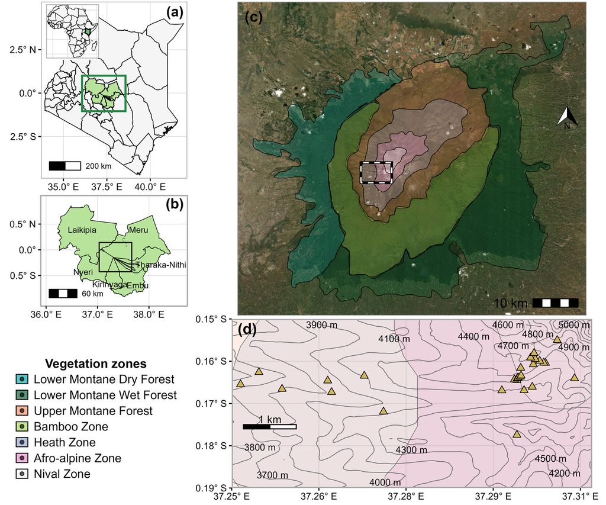

Study area and sampling on Mount Kenya

Study area and sampling on Mount Kenya. (a) Mount Kenya in central Kenya, with Kenya shown within Africa in the inset. (b) Surrounding counties (GADM v4.1). (c) Vegetation zones from the VECEA potential natural vegetation map (van Breugel et al., 2015; Lillesø et al., 2024), with the study area outlined by a dashed box. (d) Sampled plots along the elevational gradient. Grey lines mark 100-m contours from the approximately 30-m Copernicus DEM GLO-30 (European Space Agency & Airbus, 2022).

### 2.2.2 Figure 2. Morphology of Arabis alpina

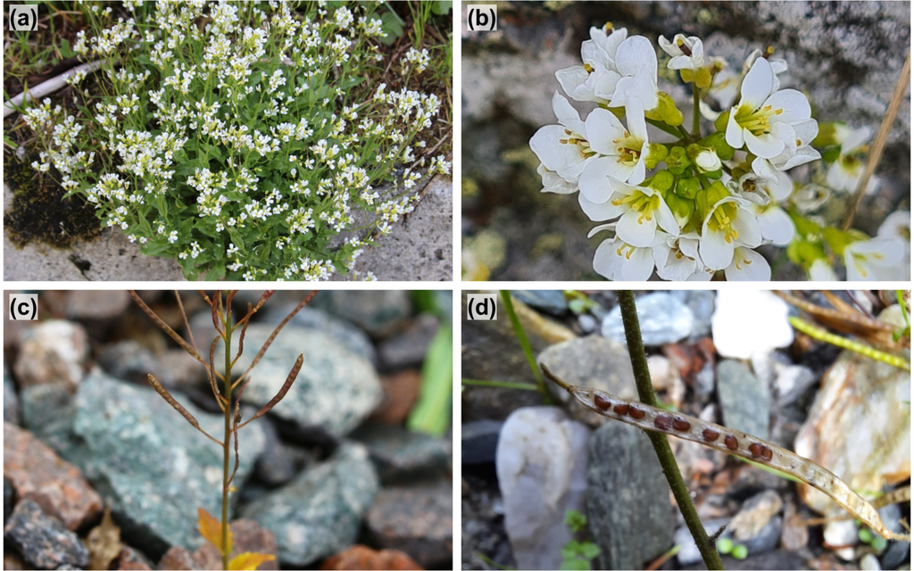

Morphology of Arabis alpina

Morphology of Arabis alpina. (a) Plant on rocky substrate (Giovanni Fontana). (b) Raceme with white, four-petalled flowers (Jacek Pietruszewski). (c) Developing siliques above the basal rosette (Johannes Hansen). (d) Dehisced siliques with mature brown seeds (karin_schrieber). Photographs are from iNaturalist (https://www.inaturalist.org) and are shown at different scales.

### 2.2.3 Figure S1. Vegetation along the Mount Kenya transect

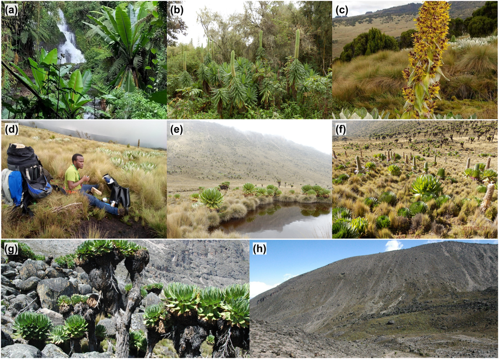

Vegetation along the Mount Kenya transect

Vegetation along the Mount Kenya transect. (a) Lower montane wet forest. (b) Upper montane forest-bamboo transition with Podocarpus spp., Hagenia abyssinica, Yushania alpina and Lobelia bambuseti. (c) Moorland with tussock grasses, sedges and Lobelia keniensis. (d) Wet Afro-alpine tussock grassland with young Lobelia rosettes. (e) Upper Afro-alpine grassland and wetland with giant rosette plants. (f) Upper Afro-alpine sedges (Carex spp.), grasses (Festuca spp.) and giant groundsels. (g) Transition to nival vegetation among boulders. (h) Sparse nival vegetation and scree. Photographs by Gerald Kenth Kaniaru.

### 2.2.4 Figure S2. Field sampling of Arabis alpina

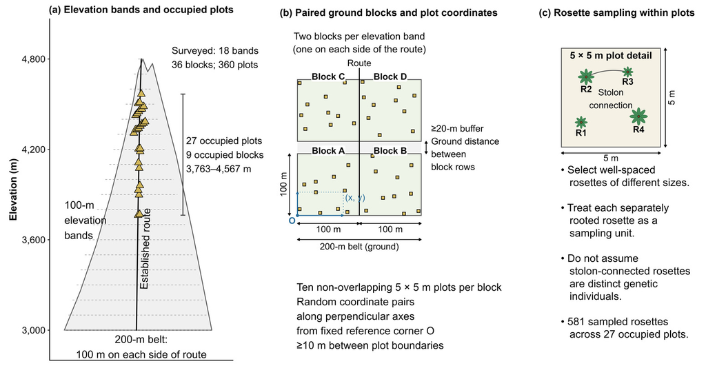

Field sampling of Arabis alpina

Field sampling of Arabis alpina. (a) The 200-m belt transect followed an established route from 3,000 to 4,800 m. Eighteen elevation bands with two blocks per band and ten plots per block yielded 36 blocks and 360 plots. Triangles show 27 occupied plots in nine blocks at 3,763-4,567 m. (b) Each block contained ten 5 × 5 m plots placed at random coordinate pairs measured from a fixed corner. Plot boundaries were at least 10 m apart and adjacent blocks were separated by at least 20 m. (c) We sampled 581 well-spaced, separately rooted rosettes of varying size. Stolon-connected rosettes could share a genotype. Positions and distances are schematic.

# 3 Exploratory analysis and diagnostics

The scripts inspect trait distributions, assess saved model fits, and calculate Spearman rank correlations. Correlations involving measured 100-seed mass are restricted to the four germination components.

## 3.1 Distributions, residual checks and correlations code

**Source:** `scripts/05a_data_distribution.R`

```r
# 1. Local publication support functions -------------------------------------

# Local definitions: this script never sources another R file.
publication_root <- "outputs"
publication_captions <- c(
  Figure_S3 = "Figure S3. Distributions of environmental predictors and reproductive traits. Histograms show densities and black curves show smoothed density estimates. Yellow bars indicate original scales and grey bars indicate natural-log scales. MISM is mean individual seed mass (mg per seed)."
)
publication_figure_exports <- function() {
  from <- file.path(publication_root, "diagnostics/data_distributions/distributions_all_variables")
  to <- file.path(dirname(from), "Figure_S3_distributions")
  records <- list()
  for (ext in c("png", "pdf", "tiff")) {
    input <- paste0(from, ".", ext)
    output <- paste0(to, ".", ext)
    if (file.exists(input)) {
      # A publication filename may already be the source filename.
      input_path <- normalizePath(input, winslash = "/", mustWork = TRUE)
      output_path <- file.path(
        normalizePath(dirname(output), winslash = "/", mustWork = TRUE),
        basename(output)
      )
      if (file.exists(output)) {
        output_path <- normalizePath(output, winslash = "/", mustWork = TRUE)
      }
      if (.Platform$OS.type == "windows") {
        input_path <- tolower(input_path)
        output_path <- tolower(output_path)
      }
      if (!identical(input_path, output_path)) {
        stopifnot(file.copy(input, output, overwrite = TRUE))
      }
      records[[length(records) + 1L]] <- data.frame(Number = "Figure S3", Format = ext, File = output)
    }
  }
  if (!length(records)) {
    return(invisible(NULL))
  }
  writeLines(publication_captions[["Figure_S3"]], paste0(to, "_caption.txt"))
  writeLines(publication_captions[["Figure_S3"]], paste0(from, "_caption.txt"))
  manifest_file <- file.path(publication_root, "Publication_figure_manifest.csv")
  updated <- do.call(rbind, records)
  if (file.exists(manifest_file)) {
    previous <- utils::read.csv(manifest_file, stringsAsFactors = FALSE)
    previous <- previous[previous$Number != "Figure S3", , drop = FALSE]
    updated <- rbind(previous[, names(updated), drop = FALSE], updated)
  }
  utils::write.csv(updated, manifest_file, row.names = FALSE)
  invisible(updated)
}
# END INLINE PUBLICATION SUPPORT

# Flowering calendar: 1 June 2021 = Day 1; date = 2021-06-01 + day - 1.
# Duration = final flowering day minus onset day (elapsed days).
# ============================================================================

# Script 05a: DISTRIBUTION AND SKEWNESS AUDIT

# Examines the climate, phenology, soil and seed variables used in the models.

# Run from the "arabis analysis" project root.

# ============================================================================

# 2. Packages and output directories -----------------------------------------

required <- c("readxl", "dplyr", "tidyr", "ggplot2", "germinationmetrics")
missing <- required[!vapply(required, requireNamespace, logical(1), quietly = TRUE)]
if (length(missing)) {
  stop("Install the required packages: ", paste(missing, collapse = ", "))
}
suppressPackageStartupMessages({
  library(readxl)
  library(dplyr)
  library(tidyr)
  library(ggplot2)
})
if (!file.exists("arabis analysis.Rproj")) {
  stop("Run this script from the 'arabis analysis' project root.")
}
input_dir <- file.path("data", "raw", "Datasets")
output_dir <- file.path("outputs", "diagnostics", "data_distributions")
dir.create(output_dir, recursive = TRUE, showWarnings = FALSE)

# 3. Read and select the requested variables ---------------------------------

plot_abiotic_factors <- read_excel(
  file.path(input_dir, "plot_abiotic_factors.xlsx"),
  sheet = "June summary",
  skip = 3,
  .name_repair = "unique"
) |>
  transmute(
    PlotID = as.character(Plot_ID),
    June_mean_temperature_C = as.numeric(June_mean_temperature_C),
    June_total_precipitation_mm = as.numeric(June_total_precipitation_mm)
  )
trait_data <- read_excel(
  file.path(input_dir, "trait_data.xlsx"),
  sheet = "Sheet2",
  .name_repair = "unique"
) |>
  transmute(
    Plant = plant_no, PlotID = paste(Block, Plot, Elevation, sep = "_"),
    FloweringOnset = as.numeric(FloweringOnset),
    FloweringDuration = as.numeric(Final_flowering_date) - as.numeric(FloweringOnset),
    Electrical.Conductivity = as.numeric(Electrical.Conductivity),
    pH = as.numeric(pH),
    Carbon = as.numeric(Carbon),
    Nitrogen = as.numeric(Nitrogen),
    Phosphorus = as.numeric(Phosphorus),
    TotalSeedNumber = as.numeric(TotalSeedNumber),
    MISM = as.numeric(MISM),
    `100_seed_mass` = as.numeric(`100_seed_mass`)
  )
plant_climate <- trait_data |>
  select(Plant, PlotID) |>
  left_join(plot_abiotic_factors, by = "PlotID")
# Plant-level germination indices from the four replicate dishes per maternal plant.

# 4. Germination count import and protocol validation ------------------------

# Cumulative counts: four dishes of 25 seeds (100 seeds per maternal plant).
read_germination_counts <- function(count_file, trait_file) {
  counts <- readxl::read_excel(count_file, sheet = "Sheet 1") |>
    dplyr::transmute(
      Day = as.numeric(Day), plant_no = as.integer(Plant_no),
      Replicate = as.integer(Replicate), Count = as.numeric(Germination_records)
    )
  plants <- readxl::read_excel(trait_file, sheet = "Sheet2") |>
    dplyr::select(plant_no, Block, Plot, Elevation, VegetationZone)
  if (anyNA(counts) || anyNA(plants) || anyDuplicated(plants$plant_no) ||
    anyDuplicated(counts[c("plant_no", "Replicate", "Day")]) ||
    any(counts$Count < 0 | counts$Count > 25 | counts$Count != floor(counts$Count))) {
    stop("Invalid plant IDs, duplicate records, missing values or counts outside 0-25 per dish.")
  }
  if (!setequal(counts$plant_no, plants$plant_no)) {
    stop("Germination and trait workbooks must contain the same plant IDs.")
  }
  checks <- counts |>
    dplyr::arrange(plant_no, Replicate, Day) |>
    dplyr::group_by(plant_no, Replicate) |>
    dplyr::summarise(Valid = identical(Day, as.numeric(0:34)) &&
      dplyr::first(Count) == 0 && all(diff(Count) >= 0), .groups = "drop")
  if (any(!checks$Valid) || !setequal(checks$Replicate, 1:4) || any(table(checks$plant_no) != 4L)) {
    stop("Expected four cumulative replicate series per plant, days 0-34, starting at zero.")
  }
  assignments <- plants |>
    dplyr::mutate(Source_plot_ID = paste(Block, Plot, Elevation, sep = "_"))
  plant_counts <- counts |>
    dplyr::group_by(plant_no, Day) |>
    dplyr::summarise(Cumulative_germination = sum(Count), .groups = "drop") |>
    dplyr::left_join(plants, by = "plant_no")
  # Sum only the four dishes belonging to the same maternal plant.
  trajectories <- plant_counts |>
    dplyr::select(plant_no, Day, Cumulative_germination) |>
    dplyr::filter(Day > 0)
  list(trajectories = trajectories, assignments = assignments)
}
# End of germination count import and protocol validation.
```

```r
germination_input <- read_germination_counts(
  file.path(input_dir, "germination_counts.xlsx"), file.path(input_dir, "trait_data.xlsx")
)
plant_trajectories <- germination_input$trajectories
calculate_indices <- function(data) {
  data <- arrange(data, Day)
  cumulative <- data$Cumulative_germination
  days <- data$Day
  if (!any(cumulative > 0)) {
    return(tibble(
      t0 = NA_real_, tg = NA_real_, Time_spread = NA_real_,
      MGR = NA_real_, Final_germination = 0, GP = 0
    ))
  }
  tibble(
    t0 = germinationmetrics::FirstGermTime(cumulative, days, partial = FALSE),
    tg = germinationmetrics::LastGermTime(cumulative, days, partial = FALSE),
    Time_spread = germinationmetrics::TimeSpreadGerm(cumulative, days,
      partial = FALSE
    ),
    MGR = germinationmetrics::MeanGermRate(cumulative, days, partial = FALSE),
    Final_germination = max(cumulative),
    GP = 100 * max(cumulative) / 100
  )
}
indices <- plant_trajectories |>
  group_by(plant_no) |>
  group_modify(~ calculate_indices(.x)) |>
  ungroup()
germination_data <- indices |> select(plant_no, t0, Time_spread, MGR, GP)
if (nrow(germination_data) != nrow(trait_data) || anyDuplicated(germination_data$plant_no)) {
  stop("Expected one germination-index record per maternal plant.")
}
germination_variables <- c("t0", "Time_spread", "MGR", "GP")

distribution_data <- bind_rows(
  plant_climate |>
    select(-Plant, -PlotID) |>
    pivot_longer(everything(), names_to = "Variable", values_to = "Value") |>
    mutate(Dataset = "plot_abiotic_factors", Observation_level = "plant record"),
  trait_data |>
    select(-Plant, -PlotID) |>
    pivot_longer(everything(), names_to = "Variable", values_to = "Value") |>
    mutate(Dataset = "trait_data", Observation_level = "plant record")
) |>
  bind_rows(
    trait_data |>
      transmute(LogMISM = log(if_else(MISM > 0, MISM, NA_real_))) |>
      pivot_longer(everything(), names_to = "Variable", values_to = "Value") |>
      mutate(Dataset = "trait_data", Observation_level = "plant record"),
    germination_data |>
      select(-plant_no) |>
      pivot_longer(everything(), names_to = "Variable", values_to = "Value") |>
      mutate(Dataset = "germination_counts", Observation_level = "plant record")
  ) |>
  mutate(
    Variable = factor(
      Variable,
      levels = c(
        "June_mean_temperature_C", "June_total_precipitation_mm",
        "FloweringOnset", "FloweringDuration", "Electrical.Conductivity",
        "pH", "Carbon", "Nitrogen", "Phosphorus", "TotalSeedNumber",
        "MISM", "100_seed_mass", "LogMISM",
        "t0", "Time_spread", "MGR", "GP"
      )
    )
  )

# Adjusted Fisher-Pearson sample skewness. Positive values indicate a longer

# right tail; negative values indicate a longer left tail.
adjusted_skewness <- function(x) {
  x <- x[is.finite(x)]
  n <- length(x)
  if (n < 3L || stats::sd(x) == 0) {
    return(NA_real_)
  }
  z <- (x - mean(x)) / stats::sd(x)
  n / ((n - 1) * (n - 2)) * sum(z^3)
}
classify_skewness <- function(x) {
  case_when(
    is.na(x) ~ NA_character_,
    abs(x) < 0.5 ~ "approximately symmetric",
    abs(x) < 1 ~ if_else(x > 0, "moderately right-skewed", "moderately left-skewed"),
    x >= 1 ~ "strongly right-skewed",
    TRUE ~ "strongly left-skewed"
  )
}
safe_shapiro_p <- function(x) {
  x <- x[is.finite(x)]
  if (length(x) < 3L || length(unique(x)) < 3L) {
    return(NA_real_)
  }

  # shapiro.test accepts at most 5,000 observations. The fixed seed makes any

  # necessary subsampling reproducible.
  if (length(x) > 5000L) {
    set.seed(12191)
    x <- sample(x, 5000L)
  }
  stats::shapiro.test(x)$p.value
}
distribution_summary <- distribution_data |>
  group_by(Dataset, Observation_level, Variable) |>
  summarise(
    N_total = n(),
    N_non_missing = sum(is.finite(Value)),
    N_missing = sum(!is.finite(Value)),
    Mean = mean(Value, na.rm = TRUE),
    SD = sd(Value, na.rm = TRUE),
    Minimum = min(Value, na.rm = TRUE),
    Q1 = quantile(Value, 0.25, na.rm = TRUE, names = FALSE),
    Median = median(Value, na.rm = TRUE),
    Q3 = quantile(Value, 0.75, na.rm = TRUE, names = FALSE),
    Maximum = max(Value, na.rm = TRUE),
    IQR = IQR(Value, na.rm = TRUE),
    Adjusted_Fisher_Pearson_skewness = adjusted_skewness(Value),
    Shapiro_Wilk_P = safe_shapiro_p(Value),
    Potential_outliers_below_1.5_IQR = sum(
      Value < quantile(Value, 0.25, na.rm = TRUE) - 1.5 * IQR(Value, na.rm = TRUE),
      na.rm = TRUE
    ),
    Potential_outliers_above_1.5_IQR = sum(
      Value > quantile(Value, 0.75, na.rm = TRUE) + 1.5 * IQR(Value, na.rm = TRUE),
      na.rm = TRUE
    ),
    .groups = "drop"
  ) |>
  mutate(
    Skewness_interpretation = classify_skewness(Adjusted_Fisher_Pearson_skewness)
  )
write.csv(distribution_summary,
  file.path(output_dir, "Table_distribution_summary_all_variables.csv"),
  row.names = FALSE
)

write.csv(filter(distribution_summary, as.character(Variable) %in% germination_variables),
  file.path(output_dir, "Table_distribution_summary_germination_indices.csv"),
  row.names = FALSE
)

# 5. Diagnostic figures ------------------------------------------------------

plot_data <- distribution_data |> filter(is.finite(Value))

# 6. Publication-style distribution figure -----------------------------------

# Retain every requested raw variable and add the log-transformed seed-mass

# distribution used in the seed-mass models. The transformation is shown as a

# separate panel so the original measurement scale remains visible.
distribution_labels <- c(
  June_mean_temperature_C = "Mean June temperature\n(°C)",
  June_total_precipitation_mm = "Total June precipitation\n(mm)",
  FloweringOnset = "Flowering onset (days)",
  FloweringDuration = "Flowering duration (days)",
  Electrical.Conductivity = "Electrical conductivity",
  pH = "Soil pH",
  Carbon = "Soil organic carbon",
  Nitrogen = "Total nitrogen",
  Phosphorus = "Extractable phosphorus",
  TotalSeedNumber = "Total seed number\nper plant",
  MISM = "Mean individual seed mass\n(MISM; mg)",
  `100_seed_mass` = "100-seed mass (mg)",
  LogMISM = "ln(MISM)",
  t0 = "Time to first germination (days)",
  Time_spread = "Germination-time spread (days)",
  MGR = "Mean germination rate (day⁻¹)",
  GP = "Germination percentage (%)"
)
publication_distribution_data <- plot_data |>
  mutate(
    Variable = as.character(Variable),
    Transformation = if_else(Variable %in% c("LogMISM"),
      "Natural-log transformed", "Untransformed"
    ),
    Display_variable = factor(unname(distribution_labels[Variable]),
      levels = unname(distribution_labels)
    )
  )
publication_distribution_plot <- ggplot(
  publication_distribution_data, aes(x = Value)
) +
  geom_histogram(
    aes(y = after_stat(density), fill = Transformation),
    bins = 24, colour = "black", linewidth = .35
  ) +
  geom_density(
    colour = "black", linewidth = .75, adjust = 1,
    na.rm = TRUE
  ) +
  scale_fill_manual(values = c(
    "Untransformed" = "#D9AE00",
    "Natural-log transformed" = "#E5E5E5"
  ), guide = "none") +
  facet_wrap(~Display_variable,
    scales = "free", ncol = 4, nrow = 5,
    labeller = label_wrap_gen(width = 28)
  ) +
  labs(
    x = NULL, y = "Density"
  ) +
  theme_bw(base_size = 11, base_family = "Arial") +
  theme(
    text = element_text(family = "Arial", colour = "black"),
    strip.background = element_rect(
      fill = "#D9D9D9", colour = "grey30",
      linewidth = .55
    ),
    strip.text = element_text(
      face = "plain", colour = "black", size = 16,
      margin = margin(4, 3, 4, 3)
    ),
    axis.text.x = element_text(colour = "black", size = 13, face = "plain"),
    axis.text.y = element_text(colour = "black", size = 13, face = "plain"),
    panel.grid.minor = element_blank(),
    panel.spacing = grid::unit(5, "mm"),
    plot.margin = margin(6, 6, 5, 6, unit = "mm")
  )
ggsave(
  file.path(output_dir, "distributions_all_variables.png"),
  publication_distribution_plot,
  width = 400, height = 450,
  units = "mm", dpi = 600, bg = "white"
)
ggsave(
  file.path(output_dir, "distributions_all_variables.pdf"),
  publication_distribution_plot,
  width = 400, height = 450,
  units = "mm", device = cairo_pdf, bg = "white"
)
ggsave(
  file.path(output_dir, "distributions_all_variables.tiff"),
  publication_distribution_plot,
  width = 400, height = 450,
  units = "mm", dpi = 600, compression = "lzw", bg = "white"
)
qq_plot <- ggplot(filter(plot_data, !Variable %in% germination_variables), aes(sample = Value)) +
  stat_qq(shape = 21, fill = "#69B3A2", colour = "black", size = 1.4) +
  stat_qq_line(colour = "#B2182B", linewidth = 0.55) +
  facet_wrap(~Variable, scales = "free", ncol = 4, nrow = 4) +
  labs(x = "Theoretical quantiles", y = "Observed quantiles") +
  theme_bw(base_size = 10, base_family = "Arial") +
  theme(strip.text = element_text(face = "bold"), panel.grid.minor = element_blank())
ggsave(
  file.path(output_dir, "QQ_plots_all_variables.png"),
  qq_plot,
  width = 300, height = 300, units = "mm", dpi = 400, bg = "white"
)
# Matching four-panel diagnostics for the four germination responses.
germination_qq_plot <- qq_plot %+%
  filter(publication_distribution_data, Variable %in% germination_variables) +
  facet_wrap(~Display_variable, scales = "free", ncol = 2, nrow = 2)
ggsave(file.path(output_dir, "QQ_plots_germination_indices.png"),
  germination_qq_plot,
  width = 300, height = 300,
  units = "mm", dpi = 400, bg = "white"
)
```

```r
message("Distribution audit complete. Outputs written to: ", output_dir)
print(distribution_summary, n = Inf)

# 7. Numbered publication exports --------------------------------------------

# Numbered publication exports preserve the descriptive working filenames.

publication_figure_exports()
```

**Source:** `scripts/05b_model_residuals.R`

```r
# Assess Gaussian mixed-model residuals before selecting response transformations.
# Run from the analysis root; missing saved models are fitted here for diagnostics.
# Uses identical observations, fixed effects and random effects for raw/log comparisons.

# 1. Packages and output directories -----------------------------------------

required <- c("lme4", "glmmTMB")
for (p in required) if (!requireNamespace(p, quietly = TRUE)) stop("Missing package: ", p)
suppressPackageStartupMessages(library(lme4))
root <- "outputs"
out <- file.path(root, "diagnostics", "model_residuals")
dir.create(out, recursive = TRUE, showWarnings = FALSE)

# 2. Discover and collect saved Gaussian models ------------------------------

files <- list.files(root, pattern = "^(Models_.*|final_flowering_date_onset_models)\\.rds$", recursive = TRUE, full.names = TRUE)
models <- list()
collect <- function(x, id) {
  if (inherits(x, "lmerMod")) {
    models[[id]] <<- x
  } else if (inherits(x, "glmmTMB")) {
    if (family(x)$family == "gaussian") stop("Gaussian glmmTMB model requires implementation: ", id)
  } else if (is.list(x)) {
    nm <- names(x)
    if (is.null(nm)) nm <- seq_along(x)
    for (i in seq_along(x)) collect(x[[i]], paste(id, nm[i], sep = "__"))
  }
}
for (f in files) collect(readRDS(f), tools::file_path_sans_ext(basename(f)))

# 3. Fit diagnostic candidates when saved models are unavailable -------------

model_source <- "Saved Gaussian mixed models from scripts 06-10."
if (!length(models)) {
  message("No saved Gaussian models found; fitting diagnostic candidates directly from data/raw/Datasets.")
  for (p in c("readxl", "dplyr", "germinationmetrics")) {
    if (!requireNamespace(p, quietly = TRUE)) stop("Missing package: ", p)
  }
  suppressPackageStartupMessages(library(dplyr))
  input <- file.path("data", "raw", "Datasets")
  traits <- readxl::read_excel(file.path(input, "trait_data.xlsx"), sheet = "Sheet2")
  plants <- traits |> transmute(
    plant_no = as.integer(plant_no), Block = factor(Block), Plot = as.integer(Plot),
    Elevation = as.numeric(Elevation), PlotID = paste(Block, Plot, Elevation, sep = "_"),
    Onset = as.numeric(FloweringOnset), FinalDate = as.numeric(Final_flowering_date),
    Duration = FinalDate - Onset, LogMISM = log(as.numeric(MISM)),
    Seed_mass_100_mg = as.numeric(`100_seed_mass`),
    Carbon = as.numeric(Carbon), pH = as.numeric(pH),
    EC = as.numeric(Electrical.Conductivity), Nitrogen = as.numeric(Nitrogen),
    Phosphorus = as.numeric(Phosphorus)
  )
  climate <- readxl::read_excel(file.path(input, "plot_abiotic_factors.xlsx"),
    sheet = "June summary", skip = 3
  ) |> transmute(
    PlotID = as.character(Plot_ID),
    Temperature = as.numeric(June_mean_temperature_C),
    Precipitation = as.numeric(June_total_precipitation_mm)
  )
  plots <- plants |>
    group_by(PlotID) |>
    summarise(across(c(Elevation, Carbon, pH, EC, Nitrogen, Phosphorus), mean), .groups = "drop") |>
    left_join(climate, by = "PlotID")
  stopifnot(nrow(plots) == 27L, !anyDuplicated(climate$PlotID))
  soil <- prcomp(select(plots, Carbon, pH, EC, Nitrogen, Phosphorus), center = TRUE, scale. = TRUE)
  direction <- if (mean(soil$rotation[c("Carbon", "pH", "Nitrogen", "Phosphorus"), "PC1"]) < 0) -1 else 1
  plots$SoilPC1 <- soil$x[, "PC1"] * direction
  for (v in c("Elevation", "Temperature", "Precipitation", "SoilPC1")) {
    plots[[paste0(v, "_z")]] <- as.numeric(scale(plots[[v]]))
  }
  plants <- left_join(plants, select(plots, PlotID, ends_with("_z")), by = "PlotID") |>
    mutate(Onset_centered = Onset - mean(Onset, na.rm = TRUE))
  env <- list(
    elevation = "Elevation_z",
    elevation_climate = c("Elevation_z", "Temperature_z", "Precipitation_z"),
    elevation_soil = c("Elevation_z", "SoilPC1_z"),
    elevation_climate_soil = c("Elevation_z", "Temperature_z", "Precipitation_z", "SoilPC1_z")
  )
  flowering <- plants |> filter(complete.cases(
    Onset, Duration, Elevation_z,
    Temperature_z, Precipitation_z, SoilPC1_z, Block, PlotID
  ))
  fit_diagnostic <- function(response, terms, data, id, flowering_fit = FALSE) {
    fm <- as.formula(paste(response, "~", paste(c(terms, "(1 | Block)", "(1 | PlotID)"), collapse = " + ")))
    if (flowering_fit) {
      models[[id]] <<- lmer(fm,
        data = data, REML = FALSE,
        control = lmerControl(optimizer = "bobyqa", check.conv.singular = "warning")
      )
    } else {
      models[[id]] <<- lmer(fm, data = data, REML = FALSE)
    }
  }
  for (response in c("Onset", "Duration", "LogMISM")) {
    d <- if (response == "LogMISM") {
      plants |> filter(complete.cases(
        LogMISM,
        Elevation_z, Temperature_z, Precipitation_z, SoilPC1_z, Block, PlotID
      ))
    } else {
      flowering
    }
    for (s in names(env)) {
      fit_diagnostic(
        response, env[[s]], d,
        paste(response, s, sep = "__"), response != "LogMISM"
      )
    }
  }
  for (response in c("Duration", "FinalDate")) {
    onset_sets <- c(list(onset = character()), env)
    for (s in names(onset_sets)) {
      fit_diagnostic(
        response,
        c("Onset_centered", onset_sets[[s]]), flowering, paste("H3", response, s, sep = "__"), TRUE
      )
    }
  }
  flowering <- flowering |>
    group_by(PlotID) |>
    mutate(Onset_plot_mean = mean(Onset), Onset_within = Onset - Onset_plot_mean) |>
    ungroup() |>
    mutate(Onset_among = Onset_plot_mean - mean(Onset))
  fit_diagnostic("FinalDate", c("Onset_within", "Onset_among"), flowering, "H3__within_among", TRUE)
  counts <- readxl::read_excel(file.path(input, "germination_counts.xlsx"), sheet = "Sheet 1") |>
    transmute(
      plant_no = as.integer(Plant_no), Replicate = as.integer(Replicate),
      Day = as.numeric(Day), Count = as.numeric(Germination_records)
    )
  checks <- counts |>
    arrange(plant_no, Replicate, Day) |>
    group_by(plant_no, Replicate) |>
    summarise(valid = identical(Day, as.numeric(0:34)) && first(Count) == 0 &&
      all(is.finite(Count) & Count >= 0 & Count <= 25 & Count == floor(Count)) &&
      all(diff(Count) >= 0), .groups = "drop")
  stopifnot(
    all(checks$valid), all(checks$Replicate %in% 1:4),
    all(table(checks$plant_no) == 4L), setequal(checks$plant_no, plants$plant_no)
  )
  indices <- counts |>
    group_by(plant_no, Day) |>
    summarise(Count = sum(Count), .groups = "drop") |>
    filter(Day > 0) |>
    group_by(plant_no) |>
    group_modify(function(.x, .y) {
      x <- arrange(.x, Day)
      if (!any(x$Count > 0)) {
        return(tibble(t0 = NA_real_, Time_spread = NA_real_, MGR = NA_real_, GP = 0))
      }
      tibble(
        t0 = germinationmetrics::FirstGermTime(x$Count, x$Day, partial = FALSE),
        Time_spread = germinationmetrics::TimeSpreadGerm(x$Count, x$Day, partial = FALSE),
        MGR = germinationmetrics::MeanGermRate(x$Count, x$Day, partial = FALSE), GP = max(x$Count)
      )
    }) |>
    ungroup()
  germ <- left_join(plants, indices, by = "plant_no") |>
    mutate(Seed_mass_100_centered_mg = Seed_mass_100_mg - mean(Seed_mass_100_mg, na.rm = TRUE))
  for (response in c("t0", "Time_spread", "MGR", "GP")) {
    for (s in c("H7_elevation", "H8_unadjusted", "H8_elevation_adjusted")) {
      terms <- switch(s,
        H7_elevation = "Elevation_z",
        H8_unadjusted = "Seed_mass_100_centered_mg",
        H8_elevation_adjusted = c("Seed_mass_100_centered_mg", "Elevation_z")
      )
      fit_diagnostic(response, terms, germ, paste(response, s, sep = "__"))
    }
  }
  model_source <- paste(
    "Diagnostic-only fits made directly from current workbooks:",
    "H1-H4 environmental candidates, H3 duration/final-date and within/among models, H7 and H8.",
    "Production model files are not created; run scripts 06-10 for publication analyses."
  )
}
```

```r
# 4. Residual assessment and diagnostic plots --------------------------------

rows <- list()
assess <- function(m, id, scale) {
  r <- as.numeric(resid(m))
  z <- r / sigma(m)
  f <- as.numeric(fitted(m))
  sw <- if (length(z) >= 3 && length(z) <= 5000) shapiro.test(z)$p.value else NA_real_
  # Descriptive screen for variance changing with fitted values; not an independent-error test.
  trend <- suppressWarnings(cor(abs(z), f, method = "spearman"))
  skew <- mean((z - mean(z))^3) / sd(z)^3
  tail_fraction <- mean(abs(z) > 3)
  convergence <- m@optinfo$conv$lme4$messages
  convergence <- setdiff(convergence, "boundary (singular) fit: see help('isSingular')")
  flagged <- abs(skew) > 1 || abs(trend) > .3 || tail_fraction > .01
  rows[[length(rows) + 1L]] <<- data.frame(
    Model = id, Scale = scale, Formula = paste(deparse(formula(m)), collapse = " "),
    N = nobs(m), Residual_SD = sigma(m), Residual_skewness = skew,
    Shapiro_Wilk_P = sw, Abs_residual_fitted_Spearman = trend,
    Fraction_abs_standardized_residual_above_3 = tail_fraction,
    Singular = isSingular(m), Converged = !length(convergence),
    Assessment = if (flagged) "Review QQ, variance pattern and influential observations before choosing a transformation" else "No large descriptive residual flag; confirm visually",
    stringsAsFactors = FALSE
  )
  stem <- paste0(gsub("[^A-Za-z0-9_-]", "_", id), "__", scale)
  draw <- function() {
    par(mfrow = c(2, 2), mar = c(4, 4, 3, 1), family = "sans")
    plot(f, z, xlab = "Conditional fitted values", ylab = "Residual / residual SD", main = "Residuals versus fitted", pch = 16, col = "darkgreen")
    abline(h = 0, lty = 2)
    lines(lowess(f, z), col = "red")
    qqnorm(z, main = "Conditional residual normal Q-Q", pch = 16, col = "darkgreen")
    qqline(z, col = "red")
    hist(z, breaks = 30, main = "Conditional residual distribution", xlab = "Residual / residual SD", col = "#D9AE00")
    plot(f, sqrt(abs(z)), xlab = "Conditional fitted values", ylab = "Square root |standardized residual|", main = "Scale-location", pch = 16, col = "darkgreen")
    lines(lowess(f, sqrt(abs(z))), col = "red")
  }
  png(file.path(out, paste0(stem, ".png")), width = 2400, height = 1800, res = 250)
  draw()
  dev.off()
  pdf(file.path(out, paste0(stem, ".pdf")), width = 9.6, height = 7.2)
  draw()
  dev.off()
}

# 5. Compare original and log response models --------------------------------

raw_refits <- list()
for (id in names(models)) {
  m <- models[[id]]
  response <- as.character(formula(m)[[2]])
  logged <- response %in% c("LogMISM", "Log_MISM") || grepl("^log\\(", response)
  if (logged) {
    d <- model.frame(m)
    d$.raw_response <- exp(model.response(d))
    fm <- formula(m)
    fm[[2]] <- as.name(".raw_response")
    raw <- lmer(fm,
      data = d, REML = isREML(m),
      control = lmerControl(optimizer = "bobyqa", optCtrl = list(maxfun = 200000))
    )
    raw_refits[[id]] <- raw
    assess(raw, id, "original_response")
    assess(m, id, "existing_log_response")
  } else {
    assess(m, id, "original_response")
  }
}

# 6. Export assessments and interpretation notes -----------------------------

utils::write.csv(do.call(rbind, rows), file.path(out, "Table_Gaussian_model_residual_assessment.csv"), row.names = FALSE)
saveRDS(raw_refits, file.path(out, "Raw_response_comparison_models.rds"))
writeLines(c(
  model_source,
  "Raw-response comparisons reverse the existing natural-log response and refit the same model on the same plants.",
  "Conditional residuals assess within-plant response errors after the fitted random effects; histogram shape alone does not justify transforming the response.",
  "Shapiro-Wilk P values are descriptive: estimated mixed-model residuals are not independent observations and large samples detect small deviations.",
  "Flags use |skewness| > 1, |Spearman correlation of absolute residual with fitted| > 0.3, or >1% residuals beyond 3 residual SD. These are review screens, not automatic decision rules.",
  "Review Q-Q tails, scale-location, influential records, convergence and singularity together. Do not compare raw/log AIC without accounting for the transformation Jacobian.",
  "No production model, manuscript or existing figure is changed by this script. Gaussian glmmTMB models cause a stop rather than silent omission; non-Gaussian models are outside its scope."
), file.path(out, "README_residual_assessment.txt"))
message("Assessed ", length(models), " Gaussian models; outputs: ", out)
```

**Source:** `scripts/05c_spearman_correlations.R`

```r
# 1. Local publication support functions -------------------------------------

# Local definitions: this script never sources another R file.
publication_root <- "outputs"
publication_captions <- c(
  Figure_S5 = "Figure S5. Spearman rank correlations between environmental variables and reproductive traits. Cells show Spearman\u2019s \u03c1. Green denotes positive and brown denotes negative correlations. Soil PC1 summarises standardised soil properties. Onset and duration refer to flowering. T0, time spread (Tg \u2013 T0), MGR and GP denote germination onset, spread, mean rate and percentage. Only the lower triangle is shown. Blank cells identify untested pairs: germination responses with MISM or total seed number, and 100-seed mass with variables other than the four germination responses. MISM is mean individual seed mass (mg per seed) and equals 100-seed mass divided by 100, giving a rank correlation of one by construction. Asterisks identify Benjamini-Hochberg-adjusted P values (*, P < 0.05; **, P < 0.01; ***, P < 0.001). Unmarked values have adjusted P \u2265 0.05."
)
publication_figure_exports <- function() {
  from <- file.path(publication_root, "diagnostics/figures/spearman_correlations")
  to <- file.path(dirname(from), "Figure_S5_spearman_correlations")
  records <- list()
  for (ext in c("png", "pdf", "tiff")) {
    input <- paste0(from, ".", ext)
    output <- paste0(to, ".", ext)
    if (file.exists(input)) {
      # A publication filename may already be the source filename.
      input_path <- normalizePath(input, winslash = "/", mustWork = TRUE)
      output_path <- file.path(
        normalizePath(dirname(output), winslash = "/", mustWork = TRUE),
        basename(output)
      )
      if (file.exists(output)) {
        output_path <- normalizePath(output, winslash = "/", mustWork = TRUE)
      }
      if (.Platform$OS.type == "windows") {
        input_path <- tolower(input_path)
        output_path <- tolower(output_path)
      }
      if (!identical(input_path, output_path)) {
        stopifnot(file.copy(input, output, overwrite = TRUE))
      }
      records[[length(records) + 1L]] <- data.frame(Number = "Figure S5", Format = ext, File = output)
    }
  }
  if (!length(records)) {
    return(invisible(NULL))
  }
  writeLines(publication_captions[["Figure_S5"]], paste0(to, "_caption.txt"))
  writeLines(publication_captions[["Figure_S5"]], paste0(from, "_caption.txt"))
  manifest_file <- file.path(publication_root, "Publication_figure_manifest.csv")
  updated <- do.call(rbind, records)
  if (file.exists(manifest_file)) {
    previous <- utils::read.csv(manifest_file, stringsAsFactors = FALSE)
    previous <- previous[previous$Number != "Figure S5", , drop = FALSE]
    updated <- rbind(previous[, names(updated), drop = FALSE], updated)
  }
  utils::write.csv(updated, manifest_file, row.names = FALSE)
  invisible(updated)
}
# END INLINE PUBLICATION SUPPORT

# Flowering calendar: 1 June 2021 = Day 1; date = 2021-06-01 + day - 1.
# Duration = final flowering day minus onset day (elapsed days).
# Script 05c: PLANT-LEVEL CORRELATIONS
# Run from the arabis analysis project root, after script 05.
# The existing analysis uses Spearman rank correlations; the requested script
# and image filenames are retained without changing the statistical method.

# 2. Packages and output directories -----------------------------------------

required <- c("readxl", "dplyr", "ggplot2", "germinationmetrics")
missing <- required[!vapply(required, requireNamespace, logical(1), quietly = TRUE)]
if (length(missing)) stop("Install required packages: ", paste(missing, collapse = ", "))
suppressPackageStartupMessages({
  library(dplyr)
  library(ggplot2)
})
if (!file.exists("arabis analysis.Rproj")) stop("Run from the arabis analysis project root.")
input_dir_reporting <- file.path("data", "raw", "Datasets")
trait_file <- file.path(input_dir_reporting, "trait_data.xlsx")
source_diagnostic_table_dir <- file.path("outputs", "diagnostics", "tables")
source_diagnostic_figure_dir <- file.path("outputs", "diagnostics", "figures")
for (folder in c(source_diagnostic_table_dir, source_diagnostic_figure_dir)) {
  dir.create(folder, recursive = TRUE, showWarnings = FALSE)
}

# Updated plant-level correlations, including the recorded 100_seed_mass.

# 3. Read plant traits and prepare environmental predictors ------------------

raw_for_correlations <- readxl::read_excel(trait_file, sheet = "Sheet2", .name_repair = function(x) make.unique(x, sep = "_duplicate")) |>
  transmute(
    plant_no = as.integer(plant_no), Source_plot_ID = paste(Block, Plot, Elevation, sep = "_"),
    Elevation = as.numeric(Elevation), Onset = as.numeric(FloweringOnset),
    Duration = as.numeric(Final_flowering_date) - as.numeric(FloweringOnset), MISM = as.numeric(MISM), Seed_mass_100_mg = as.numeric(`100_seed_mass`),
    Seed_number = as.numeric(TotalSeedNumber), EC = as.numeric(Electrical.Conductivity),
    pH = as.numeric(pH), Carbon = as.numeric(Carbon), Nitrogen = as.numeric(Nitrogen),
    Phosphorus = as.numeric(Phosphorus)
  )
soil_records <- raw_for_correlations |>
  group_by(Source_plot_ID) |>
  summarise(across(c(Carbon, pH, EC, Nitrogen, Phosphorus), mean), .groups = "drop")
soil_correlations <- prcomp(select(soil_records, Carbon, pH, EC, Nitrogen, Phosphorus),
  center = TRUE, scale. = TRUE
)
soil_direction <- if (mean(soil_correlations$rotation[c("Carbon", "pH", "Nitrogen", "Phosphorus"), 1]) < 0) -1 else 1
soil_records$SoilPC1 <- soil_correlations$x[, 1] * soil_direction
raw_for_correlations <- left_join(raw_for_correlations, select(soil_records, Source_plot_ID, SoilPC1), by = "Source_plot_ID")
climate_correlations <- readxl::read_excel(file.path(input_dir_reporting, "plot_abiotic_factors.xlsx"),
  sheet = "June summary", skip = 3
) |>
  transmute(
    Source_plot_ID = as.character(Plot_ID), Temperature = as.numeric(June_mean_temperature_C),
    Precipitation = as.numeric(June_total_precipitation_mm)
  )
# Calculate the same plant-level indices used in script 08 directly from raw counts.
```

```r
# 4. Germination count import and protocol validation ------------------------

# Cumulative counts: four dishes of 25 seeds (100 seeds per maternal plant).
read_germination_counts <- function(count_file, trait_file) {
  counts <- readxl::read_excel(count_file, sheet = "Sheet 1") |>
    dplyr::transmute(
      Day = as.numeric(Day), plant_no = as.integer(Plant_no),
      Replicate = as.integer(Replicate), Count = as.numeric(Germination_records)
    )
  plants <- readxl::read_excel(trait_file, sheet = "Sheet2") |>
    dplyr::select(plant_no, Block, Plot, Elevation, VegetationZone)
  if (anyNA(counts) || anyNA(plants) || anyDuplicated(plants$plant_no) ||
    anyDuplicated(counts[c("plant_no", "Replicate", "Day")]) ||
    any(counts$Count < 0 | counts$Count > 25 | counts$Count != floor(counts$Count))) {
    stop("Invalid plant IDs, duplicate records, missing values or counts outside 0-25 per dish.")
  }
  if (!setequal(counts$plant_no, plants$plant_no)) {
    stop("Germination and trait workbooks must contain the same plant IDs.")
  }
  checks <- counts |>
    dplyr::arrange(plant_no, Replicate, Day) |>
    dplyr::group_by(plant_no, Replicate) |>
    dplyr::summarise(Valid = identical(Day, as.numeric(0:34)) &&
      dplyr::first(Count) == 0 && all(diff(Count) >= 0), .groups = "drop")
  if (any(!checks$Valid) || !setequal(checks$Replicate, 1:4) || any(table(checks$plant_no) != 4L)) {
    stop("Expected four cumulative replicate series per plant, days 0-34, starting at zero.")
  }
  assignments <- plants |>
    dplyr::mutate(Source_plot_ID = paste(Block, Plot, Elevation, sep = "_"))
  plant_counts <- counts |>
    dplyr::group_by(plant_no, Day) |>
    dplyr::summarise(Cumulative_germination = sum(Count), .groups = "drop") |>
    dplyr::left_join(plants, by = "plant_no")
  # Sum only the four dishes belonging to the same maternal plant.
  trajectories <- plant_counts |>
    dplyr::select(plant_no, Day, Cumulative_germination) |>
    dplyr::filter(Day > 0)
  list(trajectories = trajectories, assignments = assignments)
}
# End of germination count import and protocol validation.

germination_input <- read_germination_counts(
  file.path(input_dir_reporting, "germination_counts.xlsx"), trait_file
)
plant_trajectories <- germination_input$trajectories

# 5. Calculate germination indices -------------------------------------------

calculate_indices <- function(data) {
  data <- arrange(data, Day)
  cumulative <- data$Cumulative_germination
  days <- data$Day
  if (!any(cumulative > 0)) {
    return(tibble(
      t0 = NA_real_, tg = NA_real_, Time_spread = NA_real_,
      MGR = NA_real_, Final_germination = 0, GP = 0
    ))
  }
  tibble(
    t0 = germinationmetrics::FirstGermTime(cumulative, days, partial = FALSE),
    tg = germinationmetrics::LastGermTime(cumulative, days, partial = FALSE),
    Time_spread = germinationmetrics::TimeSpreadGerm(cumulative, days,
      partial = FALSE
    ),
    MGR = germinationmetrics::MeanGermRate(cumulative, days, partial = FALSE),
    Final_germination = max(cumulative),
    GP = 100 * max(cumulative) / 100
  )
}
indices <- plant_trajectories |>
  group_by(plant_no) |>
  group_modify(~ calculate_indices(.x)) |>
  ungroup()
germ_correlations <- indices |> select(plant_no, t0, Time_spread, MGR, GP)

# 6. Assemble correlation data -----------------------------------------------

correlation_data <- raw_for_correlations |>
  left_join(climate_correlations, by = "Source_plot_ID") |>
  left_join(germ_correlations, by = "plant_no") |>
  select(
    Elevation, Temperature, Precipitation, SoilPC1, Onset, Duration,
    MISM, Seed_mass_100_mg, Seed_number, t0, Time_spread, MGR, GP
  )
if (nrow(correlation_data) != nrow(germination_input$assignments) || anyNA(correlation_data)) stop("Incomplete correlation data.")

# 7. Define eligible pairs and calculate correlations ------------------------

# Restrict 100-seed mass to the four germination components before testing
# and BH adjustment; excluded pairs are absent from both table and heatmap.
germination_components <- c("t0", "Time_spread", "MGR", "GP")
n_variables <- ncol(correlation_data)
correlation_rows <- list()
for (i in 2:n_variables) {
  for (j in 1:(i - 1)) {
    # Omit these pairs from both tests and displays.
    pair_names <- c(names(correlation_data)[i], names(correlation_data)[j])
    if ("Seed_mass_100_mg" %in% pair_names &&
      !any(germination_components %in% pair_names)) {
      next
    }
    if (any(c("Seed_number", "MISM") %in% pair_names) && any(c("t0", "Time_spread", "MGR", "GP") %in% pair_names)) next
    test <- cor.test(correlation_data[[i]], correlation_data[[j]], method = "spearman", exact = FALSE)
    correlation_rows[[length(correlation_rows) + 1L]] <- data.frame(
      Row = names(correlation_data)[i], Column = names(correlation_data)[j],
      Rho = unname(test$estimate), P = test$p.value
    )
  }
}
correlation_results <- bind_rows(correlation_rows) |>
  mutate(
    Adjusted_P = p.adjust(P, "BH"),
    Stars = case_when(
      Adjusted_P < .001 ~ "***", Adjusted_P < .01 ~ "**",
      Adjusted_P < .05 ~ "*", TRUE ~ ""
    ),
    Label = if_else(
      nzchar(Stars), paste0(sprintf("%.2f", Rho), "\n", Stars),
      sprintf("%.2f", Rho)
    ),
    Row = factor(Row, levels = rev(names(correlation_data))),
    Column = factor(Column, levels = names(correlation_data))
  )

# 8. Draw and export correlation heatmap -------------------------------------

correlation_axis_labels <- c(
  MISM = "MISM",
  Seed_mass_100_mg = "100-seed mass",
  `100_seed_mass_mg` = "100-seed mass",
  Seed_number = "Seed number",
  Time_spread = "Time spread"
)
label_correlations <- function(x) {
  labels <- ifelse(x %in% names(correlation_axis_labels), unname(correlation_axis_labels[x]), x)
  as.expression(lapply(seq_along(x), function(i) {
    if (x[i] == "t0") quote(italic(T)[0]) else labels[i]
  }))
}
p_correlations <- ggplot(correlation_results, aes(Column, Row, fill = Rho)) +
  geom_tile(colour = "grey40") +
  geom_text(aes(label = Label), size = 4 + 3 / ggplot2::.pt,
    hjust = 0.5, vjust = 0.5, lineheight = 0.95, color = "black"
  ) +
  scale_fill_gradient2(low = "#79402E", mid = "white", high = "#235B38", limits = c(-1, 1)) +
  coord_equal() +
  labs(x = NULL, y = NULL, fill = "Spearman's Rho") +
  scale_x_discrete(labels = label_correlations) +
  scale_y_discrete(labels = label_correlations) +
  theme_bw(base_size = 14, base_family = "Arial") +
  theme(panel.grid = element_blank(), axis.text.x = element_text(angle = 45, hjust = 1)) +
  theme(
    text = element_text(family = "Arial"),
    legend.position = "inside", legend.position.inside = c(.94, .88),
    legend.justification = c(1, 1),
    legend.background = element_rect(fill = "white", colour = NA),
    legend.title = element_text(
      size = 15, face = "bold", color = "black",
      margin = margin(b = 4, unit = "mm")
    ),
    legend.text = element_text(size = 14, face = "plain", color = "black"),
    axis.text.x = element_text(colour = "black", size = 15, face = "plain"),
    axis.text.y = element_text(colour = "black", size = 15, face = "plain"),
    axis.title = element_text(colour = "black", size = 15, face = "bold"),
    plot.subtitle = element_text(colour = "black", size = 15, face = "bold"),
    plot.margin = margin(t = 1, r = 4, b = 1, l = 2, unit = "mm")
  )
ggsave(file.path(source_diagnostic_figure_dir, "spearman_correlations.png"), p_correlations,
  width = 300, height = 200, units = "mm", dpi = 300
)
utils::write.csv(correlation_results, file.path(source_diagnostic_table_dir, "Source_trait_correlations.csv"), row.names = FALSE)
```

```r
message("Plant-level correlation figure and table written to outputs/diagnostics.")

# 9. Numbered publication exports --------------------------------------------

# Numbered publication exports preserve the descriptive working filenames.

publication_figure_exports()
```

## 3.2 Exploratory figures

### 3.2.1 Figure S3. Distributions of environmental predictors and reproductive traits

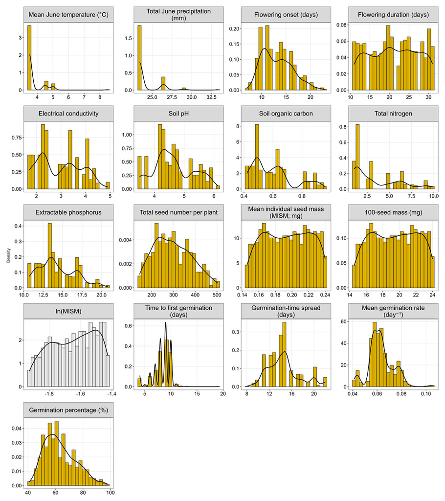

Distributions of environmental predictors and reproductive traits

Distributions of environmental predictors and reproductive traits. Histograms show densities and black curves show smoothed density estimates. Yellow bars indicate original scales and grey bars indicate natural-log scales. MISM is mean individual seed mass (mg per seed).

### 3.2.2 Figure S5. Spearman rank correlations

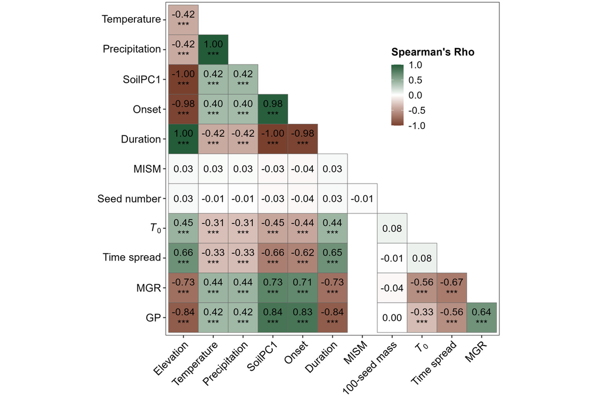

Spearman rank correlations

Spearman rank correlations between environmental variables and reproductive traits. Cells show Spearman’s ρ. Green denotes positive and brown denotes negative correlations. Soil PC1 summarises standardised soil properties. Onset and duration refer to flowering. T0, time spread (Tg – T0), MGR and GP denote germination onset, spread, mean rate and percentage. Only the lower triangle is shown. Blank cells identify untested pairs: germination responses with MISM or total seed number, and 100-seed mass with variables other than the four germination responses. MISM is mean individual seed mass (mg per seed) and equals 100-seed mass divided by 100, giving a rank correlation of one by construction. Asterisks identify Benjamini-Hochberg-adjusted P values (*, P < 0.05; **, P < 0.01;*** , P < 0.001). Unmarked values have adjusted P ≥ 0.05.

# 4 Flowering phenology and maternal seed allocation

The flowering and seed-allocation analyses examine elevational associations and relationships among traits. The onset analysis distinguishes the final-flowering-date slope from its corresponding duration interpretation. Within- and among-plot coefficients are displayed separately.

## 4.1 Flowering and seed allocation code

**Source:** `scripts/06_flowering_phenology.R`

```r
# 1. Local publication support functions -------------------------------------

# Local definitions: this script never sources another R file.
publication_root <- "outputs"
publication_captions <- c(
  Figure_3 = "Figure 3. Environmental variation across 27 source plots. (a) June 2021 mean temperature, (b) June 2021 total precipitation and (c) standardised soil PC1 by elevation, and (d) soil PC1 loadings. In (a-c), points are plots, lineas are linear fits and shading indicates 95% confidence intervals. In (d), C, N, P and EC denote organic carbon, total nitrogen, extractable phosphorus and electrical conductivity. In the fitted equations, x is elevation in metres."
)
publication_response <- function(h) {
  unname(c(
    H1 = "Flowering onset", H2 = "Flowering duration", H3 = "Final flowering date",
    H4 = "ln(MISM)", H5 = "Total seed number", H6 = "Total seed number"
  )[h])
}
publication_r2 <- function(m) {
  vf <- var(as.numeric(lme4::getME(m, "X") %*% lme4::fixef(m)))
  vr <- sum(vapply(lme4::VarCorr(m), function(v) as.numeric(v[1, 1]), numeric(1)))
  c(Marginal_R2 = vf / (vf + vr + sigma(m)^2), Conditional_R2 = (vf + vr) / (vf + vr + sigma(m)^2))
}
publication_flowering_tables <- function() {
  td <- file.path(publication_root, "flowering_phenology", "tables")
  primary_file <- file.path(td, "Table_H1_H3_primary_coefficients.csv")
  if (!file.exists(primary_file)) {
    return(invisible(NULL))
  }
  d <- utils::read.csv(primary_file, check.names = FALSE)
  models <- readRDS(file.path(publication_root, "flowering_phenology", "models", "Models_H1_H3_ML.rds"))
  completion <- readRDS(file.path(publication_root, "flowering_phenology", "models", "final_flowering_date_onset_models.rds"))
  env <- utils::read.csv(file.path(td, "Table_plot_environment.csv"))
  for (h in c("H1", "H2", "H3")) {
    m <- switch(h,
      H1 = models$H1$elevation,
      H2 = models$H2$elevation,
      H3 = completion$onset
    )
    term <- if (h == "H3") "Onset_centered" else "Elevation_z"
    cf <- coef(summary(m))[term, ]
    factor <- if (h == "H3") 1 else 100 / sd(env$Elevation)
    est <- unname(cf["Estimate"]) * factor
    se <- unname(cf["Std. Error"]) * factor
    j <- which(d$Hypothesis == h)
    stopifnot(length(j) == 1)
    d$Estimate[j] <- est
    d$SE[j] <- se
    d$CI_low[j] <- est - qnorm(.975) * se
    d$CI_high[j] <- est + qnorm(.975) * se
    d$z_approximation[j] <- est / se
    d$P_value[j] <- 2 * pnorm(-abs(est / se))
    r2 <- publication_r2(m)
    d$Marginal_R2[j] <- r2[1]
    d$Conditional_R2[j] <- r2[2]
  }
  d$Response <- publication_response(d$Hypothesis)
  d$P_zero <- d$P_value
  d$P_duration <- ifelse(d$Hypothesis == "H3", 2 * pnorm(-abs((d$Estimate - 1) / d$SE)), NA_real_)
  d$Null_for_duration <- ifelse(d$Hypothesis == "H3", 1, NA_real_)
  d$Implied_duration_slope <- ifelse(d$Hypothesis == "H3", d$Estimate - 1, NA_real_)
  d$Implied_duration_CI_low <- ifelse(d$Hypothesis == "H3", d$CI_low - 1, NA_real_)
  d$Implied_duration_CI_high <- ifelse(d$Hypothesis == "H3", d$CI_high - 1, NA_real_)
  utils::write.csv(d, primary_file, row.names = FALSE)
  within_file <- file.path(td, "Table_H3_within_among_coefficients.csv")
  w <- utils::read.csv(within_file)
  # Derive both tests from the unrounded saved decomposition, not rounded CSV SEs.
  wm <- models$H3_decomposition
  for (j in seq_len(nrow(w))) {
    cf <- coef(summary(wm))[w$Term[j], ]
    est <- unname(cf["Estimate"])
    se <- unname(cf["Std. Error"])
    w$Estimate[j] <- est
    w$SE[j] <- se
    w$CI_low[j] <- est - qnorm(.975) * se
    w$CI_high[j] <- est + qnorm(.975) * se
    w$z_approximation[j] <- est / se
    w$P_value[j] <- 2 * pnorm(-abs(est / se))
    r2 <- publication_r2(wm)
    w$Marginal_R2[j] <- r2[1]
    w$Conditional_R2[j] <- r2[2]
  }
  w$Response <- "Final flowering date"
  w$P_zero <- w$P_value
  w$P_duration <- 2 * pnorm(-abs((w$Estimate - 1) / w$SE))
  w$Null_for_duration <- 1
  w$Implied_duration_slope <- w$Estimate - 1
  w$Implied_duration_CI_low <- w$CI_low - 1
  w$Implied_duration_CI_high <- w$CI_high - 1
  utils::write.csv(w, within_file, row.names = FALSE)
  invisible(d)
}
publication_figure_exports <- function() {
  from <- file.path(publication_root, "flowering_phenology/figures/Figure1_environment_gradients_and_soil_PC1")
  to <- file.path(dirname(from), "Figure_3_environment_gradients_and_soil_PC1")
  records <- list()
  for (ext in c("png", "pdf", "tiff")) {
    input <- paste0(from, ".", ext)
    output <- paste0(to, ".", ext)
    if (file.exists(input)) {
      # A publication filename may already be the source filename.
      input_path <- normalizePath(input, winslash = "/", mustWork = TRUE)
      output_path <- file.path(
        normalizePath(dirname(output), winslash = "/", mustWork = TRUE),
        basename(output)
      )
      if (file.exists(output)) {
        output_path <- normalizePath(output, winslash = "/", mustWork = TRUE)
      }
      if (.Platform$OS.type == "windows") {
        input_path <- tolower(input_path)
        output_path <- tolower(output_path)
      }
      if (!identical(input_path, output_path)) {
        stopifnot(file.copy(input, output, overwrite = TRUE))
      }
      records[[length(records) + 1L]] <- data.frame(Number = "Figure 3", Format = ext, File = output)
    }
  }
  if (!length(records)) {
    return(invisible(NULL))
  }
  writeLines(publication_captions[["Figure_3"]], paste0(to, "_caption.txt"))
  writeLines(publication_captions[["Figure_3"]], paste0(from, "_caption.txt"))
  manifest_file <- file.path(publication_root, "Publication_figure_manifest.csv")
  updated <- do.call(rbind, records)
  if (file.exists(manifest_file)) {
    previous <- utils::read.csv(manifest_file, stringsAsFactors = FALSE)
    previous <- previous[previous$Number != "Figure 3", , drop = FALSE]
    updated <- rbind(previous[, names(updated), drop = FALSE], updated)
  }
  utils::write.csv(updated, manifest_file, row.names = FALSE)
  invisible(updated)
}
# END INLINE PUBLICATION SUPPORT
```

```r
# Flowering calendar: 1 June 2021 = Day 1; date = 2021-06-01 + day - 1.
# Duration = final flowering day minus onset day (elapsed days).
# ============================================================================

# Script 06: FLOWERING PHENOLOGY (H1-H3)

# Implements the statistical analysis described in manuscript Section 2.8.

# Run from the "arabis analysis" project root.

# ============================================================================

# 2. Marginal and conditional R-squared: calculation and figure notation -----

# Nakagawa marginal and conditional R-squared. No degrees-of-freedom adjustment.
model_r2 <- function(model, null_model = NULL) {
  if (inherits(model, "lm") && !inherits(model, "glm")) {
    r <- summary(model)$r.squared
    return(c(Marginal = r, Conditional = r))
  }
  if (inherits(model, "merMod")) {
    vf <- var(as.numeric(lme4::getME(model, "X") %*% lme4::fixef(model)))
    vr <- sum(vapply(lme4::VarCorr(model), function(v) as.numeric(v[1, 1]), numeric(1)))
    total <- vf + vr + sigma(model)^2
    return(c(Marginal = vf / total, Conditional = (vf + vr) / total))
  }
  if (inherits(model, "glmmTMB")) {
    # Explicit null fits avoid dependence on data/family names in saved calls.
    if (is.null(null_model)) {
      random <- lme4::findbars(formula(model))
      rhs <- paste(c("1", vapply(random, function(x) paste0("(", paste(deparse(x), collapse = ""), ")"), character(1))), collapse = " + ")
      response <- paste(deparse(formula(model)[[2]]), collapse = "")
      null_model <- suppressWarnings(glmmTMB::glmmTMB(
        as.formula(paste(response, "~", rhs)),
        data = model$frame,
        family = family(model)
      ))
    }
    values <- suppressWarnings(MuMIn::r.squaredGLMM(model, null = null_model))
    row <- if ("delta" %in% rownames(values)) "delta" else 1L
    result <- c(Marginal = unname(values[row, "R2m"]), Conditional = unname(values[row, "R2c"]))
    if (any(!is.finite(result))) stop("Non-finite mixed-model R-squared; inspect the fitted model.")
    return(result)
  }
  stop("Unsupported model class for marginal and conditional R-squared.")
}
r2_plotmath <- function(marginal, conditional, digits = 3) {
  if (is.finite(marginal) && is.finite(conditional) &&
    round(marginal, digits) == round(conditional, digits)) {
    return(c(sprintf(paste0("R[m]^2~~'&'~~R[c]^2 == %.", digits, "f"), marginal), NA_character_))
  }
  c(
    sprintf(paste0("R[m]^2 == %.", digits, "f"), marginal),
    sprintf(paste0("R[c]^2 == %.", digits, "f"), conditional)
  )
}
# End of marginal and conditional r-squared: calculation and figure notation.

# 3. Reproductive-trait figure: grey facet-strip formatting ------------------

# A single facet strip for each reproductive-trait panel.
reproductive_panel_strip <- function(plot) {
  heading <- plot$labels$subtitle
  if (is.null(heading)) stop("Panel subtitle is missing.")
  wrapped_heading <- paste(strwrap(heading, width = 32), collapse = "\n")
  if (!grepl("\n", wrapped_heading, fixed = TRUE)) wrapped_heading <- paste0(wrapped_heading, "\n")
  plot$data$.panel_heading <- wrapped_heading
  plot + facet_wrap(~.panel_heading, ncol = 1) + labs(subtitle = NULL) +
    theme(
      strip.background = element_rect(fill = "#D9D9D9", colour = "grey30"),
      strip.text = element_text(
        family = "Arial", colour = "black", face = "bold",
        size = 13, hjust = .5, lineheight = 1.05,
        margin = margin(5, 4, 5, 4)
      )
    )
}
# End of reproductive-trait figure: grey facet-strip formatting.

# 4. Packages and output directories -----------------------------------------

required <- c(
  "readxl", "dplyr", "tidyr", "ggplot2", "lme4", "performance",
  "patchwork", "ggtext"
)
missing <- required[!vapply(required, requireNamespace, logical(1), quietly = TRUE)]
if (length(missing)) stop("Install required packages: ", paste(missing, collapse = ", "))
suppressPackageStartupMessages({
  library(readxl)
  library(dplyr)
  library(tidyr)
  library(ggplot2)
  library(lme4)
  library(patchwork)
})
if (!file.exists("arabis analysis.Rproj")) {
  stop("Run this script from the 'arabis analysis' project root.")
}
set.seed(12191)

# Derive significance symbols from model P-values; never enter them manually.
significance_code <- function(p) {
  cut(p,
    breaks = c(-Inf, .001, .01, .05, Inf),
    labels = c("***", "**", "*", "ns"), right = FALSE
  ) |>
    as.character()
}
input_dir_fp <- file.path("data", "raw", "Datasets")
output_dir_fp <- file.path("outputs", "flowering_phenology")
figure_dir_fp <- file.path(output_dir_fp, "figures")
table_dir_fp <- file.path(output_dir_fp, "tables")
model_dir_fp <- file.path(output_dir_fp, "models")
diagnostic_dir_fp <- file.path(output_dir_fp, "diagnostics")
invisible(lapply(c(figure_dir_fp, table_dir_fp, model_dir_fp, diagnostic_dir_fp), dir.create,
  recursive = TRUE, showWarnings = FALSE
))

# Standardise reported precision without reducing precision used in analyses.
write.csv <- function(x, file = "", ..., row.names = TRUE) {
  x <- as.data.frame(x)
  x[] <- lapply(x, function(v) if (is.numeric(v)) round(v, 3) else v)
  utils::write.csv(x, file = file, ..., row.names = row.names)
}
theme_manuscript <- function(base_size = 11) {
  theme_bw(base_size = base_size, base_family = "Arial") +
    theme(
      text = element_text(family = "Arial", colour = "black"),
      axis.title = element_text(face = "bold", size = 12),
      axis.text = element_text(colour = "black", size = 11),
      strip.text = element_text(face = "bold"),
      panel.grid.minor = element_blank(),
      plot.subtitle = element_text(face = "bold", hjust = 0, colour = "black", size = 12),
      legend.position = "bottom"
    )
}
save_figure <- function(plot, stem, width = 190, height = 130) {
  ggsave(file.path(figure_dir_fp, paste0(stem, ".png")), plot,
    width = width,
    height = height, units = "mm", dpi = 600, bg = "white"
  )
  ggsave(file.path(figure_dir_fp, paste0(stem, ".pdf")), plot,
    width = width,
    height = height, units = "mm", device = cairo_pdf, bg = "white"
  )
}
```

```r
# 5. Data preparation --------------------------------------------------------

raw_traits <- read_excel(
  file.path(input_dir_fp, "trait_data.xlsx"),
  sheet = "Sheet2",
  .name_repair = function(x) make.unique(x, sep = "_duplicate")
)
individual <- raw_traits |>
  transmute(
    Plant = plant_no,
    Block = factor(Block),
    Plot = as.integer(Plot),
    Elevation = as.numeric(Elevation),
    PlotID = paste(Block, Plot, Elevation, sep = "_"),
    Onset = as.numeric(FloweringOnset),
    FinalDate = as.numeric(Final_flowering_date),
    Duration = as.numeric(Final_flowering_date) - as.numeric(FloweringOnset),
    MISM = as.numeric(MISM),
    SeedNumber = as.numeric(TotalSeedNumber),
    EC = as.numeric(Electrical.Conductivity),
    pH = as.numeric(pH),
    Carbon = as.numeric(Carbon),
    Nitrogen = as.numeric(Nitrogen),
    Phosphorus = as.numeric(Phosphorus)
  )
# Both dates must use the same calendar origin; duration is elapsed days.
if (any(!is.na(individual$FinalDate) & !is.finite(individual$FinalDate)) ||
  any(!is.na(individual$Onset) & !is.finite(individual$Onset)) ||
  any(individual$Duration < 0, na.rm = TRUE)) {
  stop("Invalid flowering dates: verify numeric day offsets and final date >= onset.")
}
climate <- read_excel(
  file.path(input_dir_fp, "plot_abiotic_factors.xlsx"),
  sheet = "June summary",
  skip = 3, .name_repair = function(x) make.unique(x, sep = "_duplicate")
) |>
  transmute(
    PlotID = as.character(Plot_ID),
    Temperature = as.numeric(June_mean_temperature_C),
    Precipitation = as.numeric(June_total_precipitation_mm)
  )

# 6. Environmental predictors and soil PCA preparation -----------------------

# Environmental measurements are plot-level covariates; trait responses remain plants.
prepare_plot_environment <- function(individual, climate) {
  variables <- c("PlotID", "Elevation", "Carbon", "pH", "EC", "Nitrogen", "Phosphorus")
  plots <- individual |>
    dplyr::group_by(PlotID) |>
    dplyr::summarise(dplyr::across(dplyr::all_of(setdiff(variables, "PlotID")), mean), .groups = "drop")
  if (anyDuplicated(plots$PlotID) || nrow(plots) != 27L) {
    stop("Expected 27 source plots with consistent soil measurements.")
  }
  plots <- dplyr::left_join(plots, climate, by = "PlotID")
  soil <- dplyr::select(plots, Carbon, pH, EC, Nitrogen, Phosphorus)
  if (any(!is.finite(as.matrix(soil)))) stop("Invalid soil measurements.")
  pca <- prcomp(soil, center = TRUE, scale. = TRUE)
  if (mean(pca$rotation[c("Carbon", "pH", "Nitrogen", "Phosphorus"), "PC1"]) < 0) {
    pca$rotation[, "PC1"] <- -pca$rotation[, "PC1"]
    pca$x[, "PC1"] <- -pca$x[, "PC1"]
  }
  plots$SoilPC1 <- pca$x[, "PC1"]
  for (variable in c("Elevation", "Temperature", "Precipitation", "SoilPC1")) {
    plots[[paste0(variable, "_z")]] <- as.numeric(scale(plots[[variable]]))
  }
  joined <- dplyr::left_join(individual, dplyr::select(
    plots, PlotID,
    Temperature, Precipitation, SoilPC1, dplyr::ends_with("_z")
  ), by = "PlotID")
  list(plots = plots, plants = joined, pca = pca)
}
# End of environmental predictors and soil pca preparation.

prepared_environment <- prepare_plot_environment(individual, climate)
plant_environment <- prepared_environment$plots
soil_pca <- prepared_environment$pca
individual <- prepared_environment$plants |>
  mutate(Onset_centered = Onset - mean(Onset, na.rm = TRUE))

# 7. Soil PCA and plant-level Spearman correlations --------------------------

pca_variance <- soil_pca$sdev^2
pca_table <- data.frame(
  Component = paste0("PC", seq_along(pca_variance)),
  Eigenvalue = pca_variance,
  Variance_explained_percent = 100 * pca_variance / sum(pca_variance),
  Cumulative_percent = 100 * cumsum(pca_variance) / sum(pca_variance)
)
pca_loadings <- data.frame(
  Variable = rownames(soil_pca$rotation),
  soil_pca$rotation, row.names = NULL
)
write.csv(pca_table, file.path(table_dir_fp, "Table_soil_PCA_variance.csv"), row.names = FALSE)
write.csv(pca_loadings, file.path(table_dir_fp, "Table_soil_PCA_loadings.csv"), row.names = FALSE)

# 8. Environmental gradients and soil-PC1 composition ------------------------

# Regressions are descriptive plant-level summaries used to visualise how the

# environmental predictors change along the sampled elevation gradient.
lm_panel_annotation <- function(model, slope_digits = 5,
                                observed_values = NULL, range_unit = NULL) {
  sm <- summary(model)
  co <- coef(model)
  slope_format <- paste0("%.", as.integer(slope_digits), "f")
  sign_text <- if (co[[2]] >= 0) "+" else "-"
  equation <- paste0(
    "<i>y</i> = ", sprintf("%.3f", co[[1]]), " ", sign_text, " ",
    sprintf(slope_format, abs(co[[2]])), "<i>x</i>"
  )
  p <- coef(sm)[2, "Pr(>|t|)"]
  p_text <- if (p < .001) {
    "<i>P</i> &lt; 0.001"
  } else {
    sprintf("<i>P</i> = %.3f", p)
  }
  range_text <- if (!is.null(observed_values) && !is.null(range_unit)) {
    paste0(
      "<br>(", sprintf("%.1f", min(observed_values, na.rm = TRUE)),
      "&ndash;", sprintf("%.1f", max(observed_values, na.rm = TRUE)),
      " ", range_unit, ")"
    )
  } else {
    ""
  }
  paste0(
    equation, range_text, "<br>R<sup>2</sup> = ",
    sprintf("%.3f", sm$r.squared), "<br>", p_text
  )
}
environment_scatter_panel <- function(response, y_label, colour, tag,
                                      slope_digits = 5,
                                      annotation_position = "top-right",
                                      y_limits = NULL, y_breaks = waiver(),
                                      range_unit = NULL, annotation_y = NULL) {
  fit <- lm(reformulate("Elevation", response = response),
    data = plant_environment
  )
  annotation_data <- if (annotation_position == "bottom-right") {
    data.frame(x = Inf, y = -Inf, hjust = 1.08, vjust = -.70)
  } else {
    data.frame(x = Inf, y = Inf, hjust = 1.08, vjust = 2.05)
  }
  if (!is.null(annotation_y)) {
    annotation_data$y <- annotation_y
    annotation_data$vjust <- 1
  }
  ggplot(plant_environment, aes(x = Elevation, y = .data[[response]])) +
    geom_smooth(
      method = "lm", formula = y ~ x, se = TRUE,
      colour = "grey40", fill = "#E5E5E5",
      linewidth = .9
    ) +
    geom_point(
      shape = 21, fill = scales::alpha(colour, .72),
      colour = "grey20", stroke = .65, size = 2.6
    ) +
    ggtext::geom_richtext(
      data = annotation_data,
      aes(x = x, y = y, hjust = hjust, vjust = vjust),
      label = lm_panel_annotation(
        fit, slope_digits,
        observed_values = plant_environment[[response]],
        range_unit = range_unit
      ),
      inherit.aes = FALSE, family = "Arial", size = 3.5,
      lineheight = 1.02, fill = NA, label.colour = NA,
      label.padding = grid::unit(0, "pt")
    ) +
    annotate("text",
      x = -Inf, y = Inf, label = tag,
      hjust = -.35, vjust = 1.5, family = "Arial",
      fontface = "bold", size = 4.5
    ) +
    scale_y_continuous(breaks = y_breaks) +
    coord_cartesian(ylim = y_limits) +
    labs(x = "Elevation (m)", y = y_label) +
    theme_bw(base_size = 11, base_family = "Arial") +
    theme(
      text = element_text(family = "Arial"),
      axis.text.x = element_text(colour = "black", size = 11, face = "plain"),
      axis.text.y = element_text(colour = "black", size = 11, face = "plain"),
      axis.title = element_text(colour = "black", size = 12, face = "bold"),
      plot.subtitle = element_text(colour = "black", size = 12, face = "bold"),
      plot.margin = margin(t = 1.5, r = 3, b = .5, l = 1, unit = "mm")
    )
}
p_environment_temperature <- environment_scatter_panel(
  "Temperature",
  expression(bold("Mean June temperature (" * degree * "C)")),
  "#FFFF6D", "(a)", 4.5,
  y_limits = c(2.5, 6.5),
  y_breaks = seq(2.5, 6.5, 1),
  range_unit = "&deg;C", annotation_y = 6
)
p_environment_precipitation <- environment_scatter_panel(
  "Precipitation", "Total June precipitation (mm)", "#99F9FF", "(b)", 4.5,
  y_limits = c(22, 30), y_breaks = seq(22, 30, 2), range_unit = "mm",
  annotation_y = 29
)
p_environment_soil_pc1 <- environment_scatter_panel(
  "SoilPC1_z", "Standardized soil PC1 score", "#924900", "(c)", 4.5,
  "bottom-left",
  y_limits = c(-2.5, 2.5),
  y_breaks = seq(-2.5, 2.5, 1.25), annotation_y = 1.5
)
loading_labels <- c(
  pH = "pH", Phosphorus = "P", Carbon = "C",
  Nitrogen = "N", EC = "EC"
)
loading_plot_data <- pca_loadings |>
  transmute(
    Variable = factor(unname(loading_labels[Variable]),
      levels = c("EC", "N", "C", "P", "pH")
    ),
    Loading = PC1
  )
p_environment_loadings <- ggplot(
  loading_plot_data, aes(x = Loading, y = Variable, fill = Loading > 0)
) +
  geom_vline(xintercept = 0, colour = "black", linewidth = .55) +
  geom_col(width = .68, colour = "black", linewidth = .55) +
  geom_text(
    aes(
      label = sprintf("%+.3f", Loading),
      hjust = ifelse(Loading >= 0, 1.08, -.08)
    ),
    family = "Arial", size = 3.7, colour = "black"
  ) +
  annotate("text",
    x = -Inf, y = Inf, label = "(d)",
    hjust = -.35, vjust = 1.35, family = "Arial",
    fontface = "bold", size = 4.5
  ) +
  scale_fill_manual(
    values = c(`TRUE` = "#DE77AE", `FALSE` = "#B8E186"),
    guide = "none"
  ) +
  scale_x_continuous(
    limits = c(-.52, .52), breaks = seq(-.5, .5, .25),
    expand = expansion(mult = 0)
  ) +
  labs(x = "PC1 loading", y = "Soil properties") +
  theme_bw(base_size = 11, base_family = "Arial") +
  theme(
    text = element_text(family = "Arial"),
    axis.text.x = element_text(colour = "black", size = 11, face = "plain"),
    axis.text.y = element_text(colour = "black", size = 11, face = "plain"),
    axis.title = element_text(colour = "black", size = 12, face = "bold"),
    plot.subtitle = element_text(colour = "black", size = 12, face = "bold"),
    plot.margin = margin(t = 1, r = 3, b = .2, l = 1, unit = "mm")
  )
environment_column_gap_mm <- 0.2
environment_gradient_figure <- wrap_plots(
  p_environment_temperature, plot_spacer(), p_environment_precipitation,
  p_environment_soil_pc1, plot_spacer(), p_environment_loadings,
  ncol = 3,
  widths = grid::unit(c(1, environment_column_gap_mm, 1), c("null", "mm", "null")),
  guides = "collect"
)
save_figure(
  environment_gradient_figure,
  "Figure1_environment_gradients_and_soil_PC1", 200, 150
)
```

```r
# 9. Analysis sample and model helpers ---------------------------------------

# Shared complete-case data ensure identical observations within each AICc set.
model_data <- individual |>
  filter(complete.cases(
    Onset, Duration, Elevation_z, Temperature_z,
    Precipitation_z, SoilPC1_z, Block, PlotID
  ))
fit_ml <- function(formula, data = model_data) {
  lmer(formula,
    data = data, REML = FALSE,
    control = lmerControl(
      optimizer = "bobyqa",
      check.conv.singular = "warning"
    )
  )
}
aicc_table <- function(models) {
  out <- bind_rows(lapply(names(models), function(name) {
    model <- models[[name]]
    k <- attr(logLik(model), "df")
    n <- nobs(model)
    aic <- AIC(model)
    data.frame(
      Model = name, N = n, K = k, logLik = as.numeric(logLik(model)),
      AIC = aic, AICc = aic + (2 * k * (k + 1)) / (n - k - 1)
    )
  })) |>
    arrange(AICc) |>
    mutate(
      Delta_AICc = AICc - min(AICc),
      Akaike_weight = exp(-0.5 * Delta_AICc) / sum(exp(-0.5 * Delta_AICc))
    )
  if (length(unique(out$N)) != 1L) stop("Candidate models use different observations.")
  out
}
extract_term <- function(model, term, hypothesis, model_name) {
  tab <- coef(summary(model))
  estimate <- tab[term, "Estimate"]
  se <- tab[term, "Std. Error"]
  statistic <- estimate / se
  ci <- estimate + qnorm(c(.025, .975)) * se
  if (term == "Elevation_z") {
    conversion <- 100 / sd(plant_environment$Elevation)
    estimate <- estimate * conversion
    se <- se * conversion
    ci <- ci * conversion
  }
  data.frame(
    Hypothesis = hypothesis, Model = model_name, Term = term,
    Coefficient_unit = if (term == "Elevation_z") "per 100-m elevation increase" else "per one-day onset increase",
    Estimate = estimate, SE = se, CI_low = ci[1], CI_high = ci[2],
    z_approximation = statistic, P_value = 2 * pnorm(abs(statistic), lower.tail = FALSE),
    Marginal_R2 = model_r2(model)[["Marginal"]], Conditional_R2 = model_r2(model)[["Conditional"]],
    N = nobs(model), Singular = isSingular(model, tol = 1e-4)
  )
}

# 10. H1: flowering onset ----------------------------------------------------

h1_models <- list(
  elevation = fit_ml(Onset ~ Elevation_z + (1 | Block) + (1 | PlotID)),
  elevation_climate = fit_ml(Onset ~ Elevation_z + Temperature_z + Precipitation_z +
    (1 | Block) + (1 | PlotID)),
  elevation_soil = fit_ml(Onset ~ Elevation_z + SoilPC1_z +
    (1 | Block) + (1 | PlotID)),
  elevation_climate_soil = fit_ml(Onset ~ Elevation_z + Temperature_z +
    Precipitation_z + SoilPC1_z +
    (1 | Block) + (1 | PlotID))
)

# 11. H2: flowering duration -------------------------------------------------

h2_models <- list(
  elevation = fit_ml(Duration ~ Elevation_z + (1 | Block) + (1 | PlotID)),
  elevation_climate = fit_ml(Duration ~ Elevation_z + Temperature_z + Precipitation_z +
    (1 | Block) + (1 | PlotID)),
  elevation_soil = fit_ml(Duration ~ Elevation_z + SoilPC1_z +
    (1 | Block) + (1 | PlotID)),
  elevation_climate_soil = fit_ml(Duration ~ Elevation_z + Temperature_z +
    Precipitation_z + SoilPC1_z +
    (1 | Block) + (1 | PlotID))
)

# 12. H3: flowering duration versus onset ------------------------------------

h3_models <- list(
  onset = fit_ml(Duration ~ Onset_centered + (1 | Block) + (1 | PlotID)),
  onset_elevation = fit_ml(Duration ~ Onset_centered + Elevation_z +
    (1 | Block) + (1 | PlotID)),
  onset_elevation_climate = fit_ml(Duration ~ Onset_centered + Elevation_z +
    Temperature_z + Precipitation_z +
    (1 | Block) + (1 | PlotID)),
  onset_elevation_soil = fit_ml(Duration ~ Onset_centered + Elevation_z + SoilPC1_z +
    (1 | Block) + (1 | PlotID)),
  onset_elevation_climate_soil = fit_ml(Duration ~ Onset_centered + Elevation_z +
    Temperature_z + Precipitation_z + SoilPC1_z +
    (1 | Block) + (1 | PlotID))
)
selection <- bind_rows(
  mutate(aicc_table(h1_models), Hypothesis = "H1"),
  mutate(aicc_table(h2_models), Hypothesis = "H2"),
  mutate(aicc_table(h3_models), Hypothesis = "H3")
) |>
  select(Hypothesis, everything())
write.csv(selection, file.path(table_dir_fp, "Table_H1_H3_AICc_model_comparison.csv"),
  row.names = FALSE
)

# Decompose onset while retaining every individual plant response.
model_data <- model_data |>
  group_by(PlotID) |>
  mutate(Onset_plot_mean = mean(Onset), Onset_within = Onset - Onset_plot_mean) |>
  ungroup() |>
  mutate(Onset_among = Onset_plot_mean - mean(Onset))
h3_decomposition <- fit_ml(FinalDate ~ Onset_within + Onset_among +
  (1 | Block) + (1 | PlotID))
h3_decomposition_results <- bind_rows(
  extract_term(h3_decomposition, "Onset_within", "H3", "within_plot"),
  extract_term(h3_decomposition, "Onset_among", "H3", "among_plot")
)
write.csv(h3_decomposition_results, file.path(
  table_dir_fp,
  "Table_H3_within_among_coefficients.csv"
), row.names = FALSE)
coefficients <- bind_rows(
  extract_term(h1_models$elevation, "Elevation_z", "H1", "elevation"),
  extract_term(h2_models$elevation, "Elevation_z", "H2", "elevation"),
  extract_term(h3_models$onset, "Onset_centered", "H3", "onset")
)
write.csv(coefficients, file.path(table_dir_fp, "Table_H1_H3_primary_coefficients.csv"),
  row.names = FALSE
)
saveRDS(
  list(
    H1 = h1_models, H2 = h2_models, H3 = h3_models,
    H3_decomposition = h3_decomposition, Soil_PCA = soil_pca
  ),
  file.path(model_dir_fp, "Models_H1_H3_ML.rds")
)

# 13. Residual diagnostics ---------------------------------------------------

diagnostic_plot <- function(model, label) {
  diagnostic_data <- data.frame(
    Fitted = fitted(model), Residual = resid(model),
    Standardized_residual = as.numeric(scale(resid(model)))
  )
  residual_plot <- ggplot(diagnostic_data, aes(Fitted, Standardized_residual)) +
    geom_hline(yintercept = 0, linetype = "dashed") +
    geom_point(shape = 21, fill = "#2CB89A", alpha = .65) +
    geom_smooth(method = "loess", se = FALSE, colour = "#B2182B") +
    labs(
      subtitle = paste0(label, ": residuals versus fitted"),
      y = "Standardized residual"
    )
  qq_plot <- ggplot(diagnostic_data, aes(sample = Standardized_residual)) +
    stat_qq(shape = 21, fill = "#2CB89A") +
    stat_qq_line(colour = "#B2182B") +
    labs(subtitle = paste0(label, ": normal Q-Q"))
  (residual_plot + qq_plot) & theme_manuscript()
}
diagnostics <- diagnostic_plot(h1_models$elevation, "H1") /
  diagnostic_plot(h2_models$elevation, "H2") /
  diagnostic_plot(h3_models$onset, "H3")
ggsave(file.path(diagnostic_dir_fp, "Figure_H1_H3_residual_diagnostics.png"), diagnostics,
  width = 300, height = 300, units = "mm", dpi = 400, bg = "white"
)
```

```r
# Place annotation text exactly 1 mm inside the panel border at draw time.
geom_text_edge <- function(...) {
  annotation_layer <- ggplot2::geom_text(...)
  annotation_layer$geom <- ggplot2::ggproto(NULL, ggplot2::GeomText,
    draw_panel = function(data, panel_params, coord, parse = TRUE, na.rm = FALSE, check_overlap = FALSE, ...) {
      text <- ggplot2::GeomText$draw_panel(data, panel_params, coord, parse = TRUE, na.rm = na.rm, check_overlap = check_overlap, ...)
      text$x <- if (all(data$hjust == 0)) {
        grid::unit(1, "mm")
      } else {
        grid::unit(1, "npc") - grid::unit(1, "mm")
      }
      text
    }
  )
  annotation_layer
}

# 14. Publication figures ----------------------------------------------------

plant_points <- model_data
model_annotation_data <- function(row, x_limits, y_limits,
                                  side = c("left", "right"),
                                  vertical = c("top", "bottom")) {
  side <- match.arg(side)
  vertical <- match.arg(vertical)
  p_label <- if (row$P_value < .001) {
    "italic(P) < 0.001"
  } else {
    sprintf("italic(P) == %.3f", row$P_value)
  }
  y_positions <- if (vertical == "top") {
    y_limits[2] - diff(y_limits) * c(.10, .21, .32, .43, .54)
  } else {
    y_limits[1] + diff(y_limits) * c(.54, .43, .32, .21, .10)
  }
  data.frame(
    x = if (side == "left") {
      x_limits[1] + .04 * diff(x_limits)
    } else {
      x_limits[2] - .04 * diff(x_limits)
    },
    y = y_positions,
    hjust = if (side == "left") 0 else 1,
    label = c(
      sprintf(if (row$Hypothesis %in% c("H1", "H2")) "beta[\"100 m\"] == %.3f" else "beta == %.3f", row$Estimate),
      sprintf("\"CI: [%.3f, %.3f]\"", row$CI_low, row$CI_high),
      p_label,
      r2_plotmath(row$Marginal_R2, row$Conditional_R2)
    )
  )
}
fixed_prediction <- function(model, newdata) {
  fixed_formula <- reformulas::nobars(formula(model))
  design <- model.matrix(delete.response(terms(fixed_formula)), newdata)
  fit <- as.numeric(design %*% fixef(model))
  se <- sqrt(diag(design %*% vcov(model) %*% t(design)))
  transform(newdata,
    Fitted = fit, CI_low = fit - 1.96 * se,
    CI_high = fit + 1.96 * se
  )
}
h1_row <- coefficients |> filter(Hypothesis == "H1")
h2_row <- coefficients |> filter(Hypothesis == "H2")
h3_row <- coefficients |> filter(Hypothesis == "H3", Model == "onset")
elevation_sequence <- seq(min(model_data$Elevation), max(model_data$Elevation),
  length.out = 200
)
elevation_mean <- mean(plant_environment$Elevation)
elevation_sd <- sd(plant_environment$Elevation)
h1_prediction <- fixed_prediction(
  h1_models$elevation,
  data.frame(
    Elevation = elevation_sequence,
    Elevation_z = (elevation_sequence - elevation_mean) / elevation_sd
  )
)
h2_prediction <- fixed_prediction(
  h2_models$elevation,
  data.frame(
    Elevation = elevation_sequence,
    Elevation_z = (elevation_sequence - elevation_mean) / elevation_sd
  )
)
onset_sequence <- seq(min(model_data$Onset), max(model_data$Onset), length.out = 200)
h3_prediction <- fixed_prediction(
  h3_models$onset,
  data.frame(
    Onset = onset_sequence,
    Onset_centered = onset_sequence - mean(model_data$Onset)
  )
)
h1_annotation <- model_annotation_data(
  h1_row, range(model_data$Elevation), c(8, 24), "left", "bottom"
)
h2_annotation <- model_annotation_data(
  h2_row, range(model_data$Elevation), c(0, 32), "left"
)
h3_annotation <- model_annotation_data(
  h3_row, range(model_data$Onset), c(5, 25), "right"
)
# Match panel b: successive annotation lines occupy 10% of panel height.
h3_annotation$y <- h3_annotation$y[1] - seq(0, 4) * (25 - 10) * .10
p_h1 <- ggplot(model_data, aes(Elevation, Onset)) +
  geom_ribbon(
    data = h1_prediction, aes(x = Elevation, ymin = CI_low, ymax = CI_high),
    inherit.aes = FALSE, fill = "#E5E5E5", alpha = .6
  ) +
  geom_line(
    data = h1_prediction, aes(x = Elevation, y = Fitted), linewidth = .8,
    inherit.aes = FALSE, colour = "black",
    linetype = ifelse(h1_row$P_value < 0.05, "solid", "dashed")
  ) +
  geom_point(
    shape = 21, fill = "#2CB89A", colour = "black", size = 1.5,
    alpha = 0.55, stroke = 0.25,
    position = position_jitter(width = 8, height = 0.24, seed = 12191)
  ) +
  scale_y_continuous(breaks = seq(8, 24, by = 4)) +
  coord_cartesian(ylim = c(8, 24)) +
  geom_text_edge(
    data = h1_annotation,
    aes(x = x, y = y, label = label, hjust = hjust),
    inherit.aes = FALSE, parse = TRUE, vjust = .5,
    size = 4.8, family = "Arial", colour = "black"
  ) +
  labs(
    subtitle = "(a) Flowering onset ~ elevation",
    x = "Elevation (m)\n",
    y = "Flowering onset (days)\n"
  ) +
  theme_manuscript() +
  theme(
    text = element_text(family = "Arial"),
    axis.text.x = element_text(colour = "black", size = 12, face = "plain"),
    axis.text.y = element_text(colour = "black", size = 12, face = "plain"),
    axis.title = element_text(colour = "black", size = 13, face = "bold"),
    plot.subtitle = element_text(colour = "black", size = 13, face = "bold"),
    plot.margin = margin(t = 1, r = 4, b = 1, l = 2, unit = "mm")
  )
p_h1 <- reproductive_panel_strip(p_h1)
save_figure(p_h1, "Figure_H1_flowering_onset_elevation", 150, 120)
p_h2 <- ggplot(model_data, aes(Elevation, Duration)) +
  geom_ribbon(
    data = h2_prediction, aes(x = Elevation, ymin = CI_low, ymax = CI_high),
    inherit.aes = FALSE, fill = "#E5E5E5", alpha = .6
  ) +
  geom_line(
    data = h2_prediction, aes(x = Elevation, y = Fitted), linewidth = .8,
    inherit.aes = FALSE, colour = "black",
    linetype = ifelse(h2_row$P_value < 0.05, "solid", "dashed")
  ) +
  geom_point(
    shape = 21, fill = "#2CB89A", colour = "black", size = 1.5,
    alpha = 0.55, stroke = 0.25,
    position = position_jitter(width = 8, height = 0.24, seed = 12192)
  ) +
  scale_y_continuous(breaks = seq(0, 30, by = 10)) +
  coord_cartesian(ylim = c(0, 32)) +
  geom_text_edge(
    data = h2_annotation,
    aes(x = x, y = y, label = label, hjust = hjust),
    inherit.aes = FALSE, parse = TRUE, vjust = .5,
    size = 4.8, family = "Arial", colour = "black"
  ) +
  labs(
    subtitle = "(b) Flowering duration ~ elevation", x = "Elevation (m)\n",
    y = "Flowering duration (days)\n"
  ) +
  theme_manuscript() +
  theme(
    text = element_text(family = "Arial"),
    axis.text.x = element_text(colour = "black", size = 12, face = "plain"),
    axis.text.y = element_text(colour = "black", size = 12, face = "plain"),
    axis.title = element_text(colour = "black", size = 13, face = "bold"),
    plot.subtitle = element_text(colour = "black", size = 13, face = "bold"),
    plot.margin = margin(t = 1, r = 4, b = 1, l = 2, unit = "mm")
  )
p_h2 <- reproductive_panel_strip(p_h2)
save_figure(p_h2, "Figure_H2_flowering_duration_elevation", 150, 120)
p_h3 <- ggplot(model_data, aes(Onset, Duration)) +
  geom_ribbon(
    data = h3_prediction, aes(x = Onset, ymin = CI_low, ymax = CI_high),
    inherit.aes = FALSE, fill = "#E5E5E5", alpha = .6
  ) +
  geom_line(
    data = h3_prediction, aes(x = Onset, y = Fitted), linewidth = .8,
    inherit.aes = FALSE, colour = "black",
    linetype = ifelse(h3_row$P_value < 0.05, "solid", "dashed")
  ) +
  geom_point(
    shape = 21, fill = "#2CB89A", colour = "black", size = 1.5,
    alpha = 0.55, stroke = 0.25,
    position = position_jitter(width = 0.24, height = 0.24, seed = 12193)
  ) +
  scale_y_continuous(breaks = seq(10, 25, by = 5)) +
  coord_cartesian(ylim = c(10, 25), expand = TRUE) +
  geom_text_edge(
    data = h3_annotation,
    aes(x = x, y = y, label = label, hjust = hjust),
    inherit.aes = FALSE, parse = TRUE, vjust = .5,
    size = 4.8, family = "Arial", colour = "black"
  ) +
  labs(
    subtitle = "(c) Duration ~ onset",
    x = "Flowering onset (days)\n", y = "Flowering duration (days)\n"
  ) +
  theme_manuscript(12) +
  theme(
    text = element_text(family = "Arial"),
    axis.text.x = element_text(colour = "black", size = 12, face = "plain"),
    axis.text.y = element_text(colour = "black", size = 12, face = "plain"),
    axis.title = element_text(colour = "black", size = 13, face = "bold"),
    plot.subtitle = element_text(colour = "black", size = 13, face = "bold"),
    plot.margin = margin(t = 1, r = 4, b = 1, l = 2, unit = "mm")
  )
p_h3 <- reproductive_panel_strip(p_h3)
save_figure(p_h3, "Figure_H3_duration_onset", 150, 120)
```

```r
# Plant-level H3 coefficient, with block/plot random intercepts.
h3_coefficient_labels <- h3_decomposition_results |>
  mutate(
    Component = factor(Model,
      levels = c("among_plot", "within_plot"),
      labels = c("Among plots", "Within plot")
    ),
    Annotation = paste0(
      "\u03b2 = ", sprintf("%.3f", Estimate),
      if_else(P_value < .001, " ***", if_else(P_value < .01, " **", if_else(P_value < .05, " *", " ns"))),
      "\nCI: [", sprintf("%.3f", CI_low), ", ",
      sprintf("%.3f", CI_high), "]"
    )
  )
p_h3_coefficient <- ggplot(h3_coefficient_labels, aes(Estimate, as.numeric(Component))) +
  geom_vline(xintercept = 0, linetype = 2) +
  geom_errorbar(aes(xmin = CI_low, xmax = CI_high),
    orientation = "y", width = .20, linewidth = 1,
    colour = "#1ABC9C"
  ) +
  geom_point(size = 4, colour = "#1ABC9C") +
  geom_text(aes(x = Estimate, y = as.numeric(Component) + .22, label = Annotation),
    vjust = 0, size = 4.8, family = "Arial",
    colour = "black", lineheight = 1.15
  ) +
  scale_y_continuous(
    breaks = c(1, 2), labels = c("Among plots", "Within plot"),
    limits = c(.5, 3.1), expand = expansion(mult = 0)
  ) +
  scale_x_continuous(expand = expansion(mult = c(.75, .75))) +
  labs(
    subtitle = "(d) Final flowering date ~ onset (within and among plots)",
    x = "Final-date onset coefficient (days/day)\n", y = NULL
  ) +
  theme_manuscript() +
  theme(
    text = element_text(family = "Arial"),
    axis.text.x = element_text(colour = "black", size = 12, face = "plain"),
    axis.text.y = element_text(colour = "black", size = 13, face = "bold"),
    axis.title = element_text(colour = "black", size = 13, face = "bold"),
    plot.subtitle = element_text(colour = "black", size = 13, face = "bold"),
    plot.margin = margin(t = 1, r = 4, b = 1, l = 3, unit = "mm")
  )
p_h3_coefficient <- reproductive_panel_strip(p_h3_coefficient)
p_h3_coefficient$data$.panel_heading <- "(d) Final flowering date\n~ onset (within/among plots)"
save_figure(p_h3_coefficient, "Figure_H3_plant_level_coefficient", 150, 120)
saveRDS(
  list(p_h1 = p_h1, p_h2 = p_h2, p_h3 = p_h3, p_h3_coefficient = p_h3_coefficient),
  file.path(model_dir_fp, "Figure_objects_H1_H3.rds")
)
message("H1-H3 flowering-phenology analysis complete. Outputs: ", output_dir_fp)

# 15. Publication-ready gt tables --------------------------------------------

# Shared by analysis scripts 06-11. Run scripts from the project root.

fix_r2_rtf <- function(file) {
  text <- paste(readLines(file, warn = FALSE, encoding = "UTF-8"), collapse = "\n")
  for (suffix in c("m", "c")) {
    token <- paste0("R<sup>2</sup><sub>", suffix, "</sub>")
    replacement <- paste0("R{\\super 2}{\\sub ", suffix, "}")
    text <- paste(strsplit(text, token, fixed = TRUE)[[1]], collapse = replacement)
  }
  writeLines(text, file, useBytes = TRUE)
}
save_publication_table <- function(table, file, ...) {
  gt::gtsave(table, file, ...)
  if (tolower(tools::file_ext(file)) == "rtf") fix_r2_rtf(file)
  invisible(file)
}

format_table_2_effect <- function(x) {
  small <- !is.na(x) & x != 0 & round(x, 3) == 0
  formatted <- sprintf("%.3f", round(x, 3))
  formatted[small] <- sprintf("%.3e", x[small])
  formatted[is.na(x)] <- NA_character_
  formatted
}

format_candidate_table_export <- function(data) {
  result <- data
  for (column in intersect(c("logLik", "AIC", "AICc", "Delta_AICc"), names(result))) {
    result[[column]] <- ifelse(is.na(data[[column]]), NA_character_, sprintf("%.1f", as.numeric(data[[column]])))
  }
  if ("Akaike_weight" %in% names(result)) {
    result$Akaike_weight <- ifelse(is.na(data$Akaike_weight), NA_character_,
      sprintf("%.3f", as.numeric(data$Akaike_weight))
    )
  }
  result
}

publication_table_title <- function(stem) {
  clean <- sub("^Table_", "", stem)
  if (identical(clean, "1")) {
    return("Table 1. Flowering phenology and maternal seed allocation")
  }
  if (identical(clean, "2")) {
    return("Table 2. Elevation, maternal seed mass and germination responses")
  }
  if (identical(clean, "S1")) {
    return("Table S1. Candidate-model comparisons for flowering phenology and maternal seed allocation")
  }
  clean <- gsub("_", " ", clean)
  clean <- gsub("\\bAICc\\b", "AICc", clean)
  clean <- gsub("\\bR2\\b", "R-squared", clean)
  tools::toTitleCase(clean)
}

publication_table_subtitle <- function(stem, analysis_label) {
  type <- dplyr::case_when(
    grepl("AICc|distribution_comparison", stem, ignore.case = TRUE) ~
      "Candidate-model comparison and model-support statistics",
    grepl("coefficient|model_results", stem, ignore.case = TRUE) ~
      "Model estimates, uncertainty and goodness-of-fit statistics",
    grepl("prediction|change", stem, ignore.case = TRUE) ~
      "Model-based estimates on the reported response scale",
    grepl("diagnostic|audit|check|skewness", stem, ignore.case = TRUE) ~
      "Analysis diagnostics and quality-control summary",
    grepl("PCA|loading|scaling", stem, ignore.case = TRUE) ~
      "Dimension reduction and predictor-scaling summary",
    TRUE ~ "Analysis data and derived quantities"
  )
  paste0(analysis_label, " â€” ", type)
}

publication_column_labels <- function(columns) {
  labels <- c(
    logLik = "Log-likelihood", AIC = "AIC", AICc = "AICc",
    Delta_AICc = "Î”AICc", Akaike_weight = "Akaike weight",
    Positive_definite_Hessian = "Positive-definite Hessian",
    CI_low = "Lower 95% CI", CI_high = "Upper 95% CI",
    P_value = "P value", P_Value = "P value", p_value = "P value",
    Dispersion_P = "Dispersion P", Zero_inflation_P = "Zero-inflation P",
    Outlier_P = "Outlier P", Marginal_R2 = "RÂ²m",
    Conditional_R2 = "RÂ²c", R_squared = "RÂ²",
    IRR = "Rate ratio", IRR_low = "Rate-ratio lower CI",
    IRR_high = "Rate-ratio upper CI", SE = "SE", N = "N", K = "K",
    Percent_change_per_100m_elevation_increase =
      "% change per 100-m elevation increase",
    Percent_change_in_seed_number_per_1mg_seed_mass_decrease =
      "% change per 1-mg seed-mass decrease"
  )
  fallback <- tools::toTitleCase(gsub("_", " ", columns))
  names(fallback) <- columns
  matched <- intersect(columns, names(labels))
  fallback[matched] <- labels[matched]
  result <- as.list(fallback)
  if ("Marginal_R2" %in% columns) result$Marginal_R2 <- gt::html("R<sup>2</sup><sub>m</sub>")
  if ("Conditional_R2" %in% columns) result$Conditional_R2 <- gt::html("R<sup>2</sup><sub>c</sub>")
  result
}
```

```r
add_available_spanner <- function(table, label, columns, used) {
  available <- setdiff(intersect(columns, colnames(table$`_data`)), used)
  if (!length(available)) {
    return(list(table = table, used = used))
  }
  list(
    table = gt::tab_spanner(table,
      label = label,
      columns = tidyselect::all_of(available)
    ),
    used = c(used, available)
  )
}

build_publication_gt <- function(data, stem, analysis_label) {
  data <- as.data.frame(data, check.names = FALSE)
  stub_candidates <- c(
    "Model", "Trait", "Response", "Variable", "Component",
    "PlotID", "Plot_ID", "Distribution", "Scenario"
  )
  stub <- intersect(stub_candidates, names(data))[1]
  group <- if ("Hypothesis" %in% names(data) && !is.na(stub) &&
    stub != "Hypothesis") {
    "Hypothesis"
  } else {
    NULL
  }

  table <- if (!is.na(stub) && length(stub)) {
    gt::gt(data, rowname_col = stub, groupname_col = group)
  } else {
    gt::gt(data)
  }

  table <- table |>
    gt::tab_header(
      title = gt::md(paste0("**", publication_table_title(stem), "**")),
      subtitle = publication_table_subtitle(stem, analysis_label)
    ) |>
    gt::cols_label(.list = publication_column_labels(names(data)))

  used <- character()
  spanners <- list(
    list("Model fit and support", c(
      "N", "K", "logLik", "AIC", "AICc",
      "Delta_AICc", "Akaike_weight", "Converged",
      "Positive_definite_Hessian", "Singular"
    )),
    list("Coefficient estimate", c(
      "Estimate", "SE", "CI_low", "CI_high",
      "z_value", "z_approximation", "t_value",
      "P_value", "P_Value", "p_value"
    )),
    list("Effect on response scale", c(
      "IRR", "IRR_low", "IRR_high",
      "Percent_change_per_100m_elevation_increase",
      "Percent_change_in_seed_number_per_1mg_seed_mass_decrease"
    )),
    list("Explained variation", c("Marginal_R2", "Conditional_R2", "R_squared")),
    list("Residual diagnostics", c(
      "Dispersion_statistic", "Dispersion_P",
      "Zero_inflation_P", "Outlier_P"
    ))
  )
  for (definition in spanners) {
    result <- add_available_spanner(table, definition[[1]], definition[[2]], used)
    table <- result$table
    used <- result$used
  }

  numeric_columns <- names(data)[vapply(data, is.numeric, logical(1))]
  count_columns <- intersect(c(
    "N", "K", "n", "Count", "N_accessions",
    "Replicate", "Day"
  ), numeric_columns)
  percent_columns <- intersect(grep("percent|percentage|Percent", names(data),
    value = TRUE
  ), numeric_columns)
  p_columns <- intersect(grep("(^P_|_P$|P_value|p_value|P_Value)", names(data),
    value = TRUE
  ), numeric_columns)
  general_numeric <- setdiff(
    numeric_columns,
    union(count_columns, union(percent_columns, p_columns))
  )

  if (length(general_numeric)) {
    table <- gt::fmt_number(table,
      columns = tidyselect::all_of(general_numeric),
      decimals = 3, use_seps = TRUE
    )
  }
  # Preserve small per-mg effects rather than displaying them as zero.
  effect_columns <- intersect(c("Estimate", "SE", "CI_low", "CI_high"), general_numeric)
  h6_rows <- if (identical(stem, "2")) integer(0) else if ("Hypothesis" %in% names(data)) which(data$Hypothesis %in% c("H6", "H8b", "H8c")) else integer(0)
  if (length(effect_columns) && length(h6_rows)) {
    table <- gt::fmt_number(table,
      columns = tidyselect::all_of(effect_columns),
      rows = h6_rows, decimals = 6, use_seps = TRUE
    )
  }
  if (stem %in% c("S1", "S2", "S1_all_candidate_models")) {
    fit_columns <- intersect(c("logLik", "AIC", "AICc", "Delta_AICc"), numeric_columns)
    if (length(fit_columns)) {
      table <- gt::fmt_number(table,
        columns = tidyselect::all_of(fit_columns), decimals = 1, use_seps = TRUE
      )
    }
    if ("Akaike_weight" %in% numeric_columns) {
      table <- gt::fmt_number(table,
        columns = "Akaike_weight", decimals = 3
      )
    }
  }
  if (stem %in% c("2", "S2") && length(effect_columns)) {
    table <- gt::fmt(table,
      columns = tidyselect::all_of(effect_columns),
      fns = format_table_2_effect
    )
  }
  if (length(count_columns)) {
    table <- gt::fmt_integer(table,
      columns = tidyselect::all_of(count_columns),
      use_seps = TRUE
    )
  }
  if (length(percent_columns)) {
    table <- gt::fmt_number(table,
      columns = tidyselect::all_of(percent_columns),
      decimals = 2, pattern = "{x}%"
    )
  }
  if (length(p_columns)) {
    p_formatter <- function(x) {
      ifelse(is.na(x), "â€”", ifelse(x < .001, "<0.001", sprintf("%.3f", x)))
    }
    table <- gt::fmt(table,
      columns = tidyselect::all_of(p_columns),
      fns = p_formatter
    )
  }

  table <- table |>
    gt::sub_missing(columns = gt::everything(), missing_text = "â€”") |>
    gt::opt_row_striping() |>
    gt::opt_table_font(font = c("Arial", "Helvetica", "sans-serif")) |>
    gt::tab_options(
      table.width = gt::pct(100),
      table.font.size = gt::px(12),
      heading.align = "left",
      heading.background.color = "#E8F1F5",
      column_labels.background.color = "#D9E8EF",
      row_group.background.color = "#EEF4F7",
      stub.background.color = "#F5F8FA",
      table.border.top.color = "#244A5A",
      table.border.top.width = gt::px(2),
      table.border.bottom.color = "#244A5A",
      table.border.bottom.width = gt::px(2),
      data_row.padding = gt::px(5),
      source_notes.font.size = gt::px(10)
    ) |>
    gt::tab_style(
      style = gt::cell_text(weight = "bold", color = "#173947"),
      locations = gt::cells_column_labels()
    ) |>
    gt::tab_source_note(
      source_note = gt::md(
        paste0(
          if (stem %in% c("S1", "S1_all_candidate_models")) {
            "*Note:* logLik, AIC, AICc and Î”AICc are displayed to one decimal place; Akaike weights to three decimal places. "
          } else {
            "*Note:* Numeric results are displayed to three decimal places "
          },
          if (stem %in% c("S1", "S1_all_candidate_models")) {
            "Counts are integers. "
          } else if (identical(stem, "2")) {
            paste0(
              "with integer counts. Nonzero estimates, SEs and confidence limits that round to zero ",
              "are shown in scientific notation with three decimal places in the mantissa. "
            )
          } else {
            "with six decimals for small per-mg effects and other formats for percentages or counts. "
          },
          "Rows: ", nrow(data), ". Generated reproducibly with **gt**."
        )
      )
    )
```

```r
  if ("Delta_AICc" %in% names(data)) {
    table <- table |>
      gt::data_color(
        columns = tidyselect::all_of("Delta_AICc"),
        palette = c("#E4F3E8", "#FFF4CC", "#F7D8D5"),
        domain = c(0, max(data$Delta_AICc, na.rm = TRUE))
      ) |>
      gt::tab_footnote(
        footnote = "Lower Î”AICc indicates greater relative support within the candidate set.",
        locations = gt::cells_column_labels(columns = "Delta_AICc")
      )
  }
  if ("P_value" %in% names(data)) {
    significant_rows <- which(is.finite(data$P_value) & data$P_value < .05)
    if (length(significant_rows)) {
      table <- gt::tab_style(
        table,
        style = gt::cell_text(weight = "bold", color = "#8B1A1A"),
        locations = gt::cells_body(columns = "P_value", rows = significant_rows)
      )
    }
  }
  table
}

render_gt_tables <- function(table_dir, analysis_label, png_row_limit = 0L,
                             rtf_row_limit = 200L) {
  if (!requireNamespace("gt", quietly = TRUE)) {
    stop("Install the gt package to create publication-ready tables.")
  }
  csv_files <- list.files(table_dir, pattern = "^Table_.*\\.csv$", full.names = TRUE)
  if (!length(csv_files)) {
    return(invisible(character()))
  }
  output_dir <- file.path(table_dir, "gt")
  dir.create(output_dir, recursive = TRUE, showWarnings = FALSE)

  outputs <- character()
  for (csv_file in csv_files) {
    data <- utils::read.csv(csv_file, check.names = FALSE)
    empty_names <- which(is.na(names(data)) | !nzchar(names(data)))
    if (length(empty_names)) {
      names(data)[empty_names] <- paste0("Statistic", seq_along(empty_names))
    }
    stem <- tools::file_path_sans_ext(basename(csv_file))
    table <- build_publication_gt(data, stem, analysis_label)
    html_file <- file.path(output_dir, paste0(stem, ".html"))
    gt::gtsave(table, html_file, inline_css = TRUE)
    outputs <- c(outputs, html_file)
    if (nrow(data) <= rtf_row_limit) {
      rtf_file <- file.path(output_dir, paste0(stem, ".rtf"))
      save_publication_table(table, rtf_file)
      outputs <- c(outputs, rtf_file)
    }
    if (nrow(data) <= png_row_limit) {
      png_file <- file.path(output_dir, paste0(stem, ".png"))
      png_saved <- tryCatch(
        {
          gt::gtsave(table, png_file, zoom = 2, expand = 12)
          TRUE
        },
        error = function(e) {
          warning("PNG export skipped for ", stem, ": ", conditionMessage(e))
          FALSE
        }
      )
      if (png_saved) outputs <- c(outputs, png_file)
    }
  }
  message("Publication-ready gt tables written to: ", output_dir)
  invisible(outputs)
}
# End of publication tables: formatting, r-squared notation and exports.

# Check the onsetâ€“duration measurement relationship without changing model data.
flowering_calendar_start <- as.Date("2021-06-01")
flowering_calendar_date <- function(day) flowering_calendar_start + day - 1
flowering_date_check_data <- individual |>
  transmute(PlotID, Onset, Duration, FinalDate,
    Onset_calendar_date = flowering_calendar_date(Onset),
    Final_flowering_calendar_date = flowering_calendar_date(FinalDate)
  )
flowering_date_checks <- data.frame(
  N = nrow(individual), Day_1_calendar_date = as.character(flowering_calendar_start),
  Final_day_min = min(individual$FinalDate, na.rm = TRUE),
  Final_day_max = max(individual$FinalDate, na.rm = TRUE),
  Earliest_final_flowering_date = as.character(min(flowering_date_check_data$Final_flowering_calendar_date, na.rm = TRUE)),
  Latest_final_flowering_date = as.character(max(flowering_date_check_data$Final_flowering_calendar_date, na.rm = TRUE))
)
utils::write.csv(flowering_date_checks, file.path(
  table_dir_fp,
  "Table_H3_flowering_date_checks.csv"
), row.names = FALSE)
# Latest observed flowering date does not independently establish monitoring end.

# Reproducible environmental summaries use the 27 measured plot records.
write.csv(plant_environment, file.path(table_dir_fp, "Table_plot_environment.csv"), row.names = FALSE)
write.csv(bind_rows(lapply(c("Temperature", "Precipitation", "SoilPC1_z"), function(response) {
  fit <- lm(reformulate("Elevation", response), plant_environment)
  tab <- coef(summary(fit))
  ci <- confint(fit)[2, ]
  test <- cor.test(plant_environment$Elevation, plant_environment[[response]], method = "spearman", exact = FALSE)
  data.frame(
    Response = response, N_plots = nrow(plant_environment),
    Minimum = min(plant_environment[[response]]), Maximum = max(plant_environment[[response]]),
    Estimate_per_100m = coef(fit)[2] * 100, CI_low = ci[1] * 100, CI_high = ci[2] * 100,
    P_value = tab[2, 4], R_squared = summary(fit)$r.squared,
    Spearman_rho = unname(test$estimate), Spearman_P = test$p.value
  )
})), file.path(table_dir_fp, "Table_environment_gradient_statistics.csv"), row.names = FALSE)

# Complementary completion-timing analysis; use the same covariates as H3.
# For identical linear model designs, beta_duration = beta_final_date - 1.
# This re-expression cannot establish causality or remove onset measurement error.
completion_models <- lapply(h3_models, function(m) {
  f <- formula(m)
  f[[2]] <- as.name("FinalDate")
  fit_ml(f)
})
completion_results <- bind_rows(lapply(names(completion_models), function(nm) {
  out <- extract_term(
    completion_models[[nm]], "Onset_centered",
    "Completion timing", nm
  )
  out$P_slope_equals_1 <- 2 * pnorm(abs((out$Estimate - 1) / out$SE), lower.tail = FALSE)
  out$Implied_duration_slope <- out$Estimate - 1
  out$Implied_duration_CI_low <- out$CI_low - 1
  out$Implied_duration_CI_high <- out$CI_high - 1
  out
}))
write.csv(completion_results, file.path(
  table_dir_fp,
  "Table_final_flowering_date_onset_models.csv"
), row.names = FALSE)
write.csv(
  individual |> select(Plant, PlotID, Onset, FinalDate, Duration) |>
    mutate(
      Onset_calendar_date = flowering_calendar_date(Onset),
      Final_flowering_calendar_date = flowering_calendar_date(FinalDate)
    ),
  file.path(table_dir_fp, "Table_plant_flowering_dates_and_derived_duration.csv"),
  row.names = FALSE
)
saveRDS(completion_models, file.path(model_dir_fp, "final_flowering_date_onset_models.rds"))
# Match the H1 panel: fixed-effect confidence band, black line, green
# jittered points, parsed model statistics, grey strip and export dimensions.
completion_grid <- fixed_prediction(
  completion_models$onset,
  data.frame(
    Onset = seq(min(model_data$Onset), max(model_data$Onset), length.out = 200),
    Onset_centered = seq(min(model_data$Onset), max(model_data$Onset), length.out = 200) -
      mean(individual$Onset, na.rm = TRUE)
  )
)
completion_row <- completion_results |> filter(Model == "onset")
completion_y_limits <- range(c(
  model_data$FinalDate, completion_grid$CI_low,
  completion_grid$CI_high
), na.rm = TRUE)
completion_y_limits <- c(
  floor(completion_y_limits[1]) - 1,
  ceiling(completion_y_limits[2]) + 1
)
completion_annotation <- model_annotation_data(
  completion_row,
  range(model_data$Onset), completion_y_limits, "right", "bottom"
)
# Keep statistics below the observed points, with space above the lower border.
completion_annotation$y <- completion_y_limits[1] + diff(completion_y_limits) *
  c(.44, .35, .26, .17, .08)
p_completion <- ggplot(model_data, aes(Onset, FinalDate)) +
  geom_ribbon(
    data = completion_grid, aes(x = Onset, ymin = CI_low, ymax = CI_high),
    inherit.aes = FALSE, fill = "#E5E5E5", alpha = .6
  ) +
  geom_line(
    data = completion_grid, aes(x = Onset, y = Fitted), linewidth = .8,
    inherit.aes = FALSE, colour = "black",
    linetype = ifelse(completion_row$P_value < .05, "solid", "dashed")
  ) +
  geom_point(
    shape = 21, fill = "#2CB89A", colour = "black", size = 1.5,
    alpha = .55, stroke = .25,
    position = position_jitter(width = .15, height = .24, seed = 12191)
  ) +
  scale_y_continuous(breaks = pretty(completion_y_limits, n = 5)) +
  scale_x_continuous(breaks = seq(5, 25, by = 5)) +
  coord_cartesian(xlim = c(5, 25), ylim = completion_y_limits) +
  geom_text_edge(
    data = completion_annotation,
    aes(x = x, y = y, label = label, hjust = hjust),
    inherit.aes = FALSE, parse = TRUE, vjust = .5,
    size = 4.8, family = "Arial", colour = "black"
  ) +
  labs(
    subtitle = "Final flowering date ~ onset",
    x = "Flowering onset (days)\n",
    y = "Final flowering day (days)\n"
  ) +
  theme_manuscript() +
  theme(
    text = element_text(family = "Arial"),
    axis.text.x = element_text(colour = "black", size = 12, face = "plain"),
    axis.text.y = element_text(colour = "black", size = 12, face = "plain"),
    axis.title = element_text(colour = "black", size = 13, face = "bold"),
    plot.subtitle = element_text(colour = "black", size = 13, face = "bold"),
    plot.margin = margin(t = 1, r = 4, b = 1, l = 2, unit = "mm")
  )
p_completion <- reproductive_panel_strip(p_completion)
save_figure(p_completion, "Figure_final_flowering_date_vs_onset", 150, 120)
writeLines(
  c(
    "Line and grey 95% confidence band: mixed-model fixed effects, with block and plot intercepts set to zero.",
    "Points show individual plants with display jitter. P tests the onset slope against zero.",
    "Day 1 = 1 June 2021. The slope-equals-one test is reported in the completion-model table."
  ),
  file.path(figure_dir_fp, "Figure_final_flowering_date_vs_onset_caption.txt")
)
```